2017 Edition

In this notebook, we will learn how to use the DataFrame API and SparkSQL to perform simple data analytics tasks.

# Goals

The main goals of this notebook are the following:

1. Understand the advantages and disadvantages of using DataFrame over RDD
2. Analyze the airline data with the DataFrame API and SparkSQL

# Steps

- First, in section 1, we will go through a short introduction about the DataFrame API with a small example to see how can we use it and how it compares to the low-level RDD abstraction.
- In section 2, we delve into the details of the use case of this notebook including: providing the context, introducing the data
- In section 3, we perform data exploration and analysis

# 1. RDD and DataFrame APIs

In our previous notebooks, we have worked with RDDs (Resilient Distributed Dataset), the basic abstraction in Spark. The main reason is due to the task at hand: we have been invovled in the design of distributed algorithms.

In this laboratory session, we study (or revisit) the DataFrame API - an immutable distributed collection of data. DataFrames allow developers to impose a **structure** on a distributed collection of data, allowing higher-level abstraction; in addition, DataFrames provide a domain specific language (DSL) API to manipulate distributed, structured data. Ultimately, the goal is to make Spark accessible to a wider audience, beyond researchers and specialized data engineers.

Let's take a small example to see the difference between RDDs and DataFrames. The two cells below contain short code snippets that perform the same task: count the frequency of words in a document, then sort the result in descending order. The first snippet is the same you have been working on in the very [first notebook](https://github.com/EURECOM-CLOUDS-COURSE/Introduction/blob/master/introduction-lab.ipynb) of the CLOUDS course. The second code snippet uses the DataFrame API.

**Question 1.** Run both approaches (RDD and DataFrame) detailed below, compare their runtime, and discuss. Is the DataFrame API approach faster? Can you explain why?

```python
import time
time_start = time.time()
words = (
            # read the text file
            sc.textFile("/datasets/gutenberg/gutenberg_small.txt").repartition(16)

            # construct words from lines
            .flatMap(lambda line: line.split())

            # map each word to (word, 1)
            .map(lambda x: (x, 1))

            # reduce by key: accumulate sum the freq of the same word
            .reduceByKey(lambda freq1, freq2: freq1 + freq2)

            # swap (word, freq) to (freq, word)
            .map(lambda x: (x[1], x[0]))

            # sort result by key DESC
            .sortByKey(False)
         )
print("Runtime: {}s".format(time.time() - time_start))
print(words.take(5))
```

```
Runtime: 211.42376804351807s
[(29556020, 'the'), (18043957, 'of'), (14914748, 'and'), (12892052, 'to'), (9779124, 'a')]
```

```python
from pyspark.sql.types import *
from pyspark.sql import SQLContext
from pyspark.sql.functions import explode, split, desc
sqlContext = SQLContext(sc)
time_start = time.time()

# read the text file
df = sqlContext.read.text("/datasets/gutenberg/gutenberg_small.txt")

# show 3 samples
df.show(3)

result = (
    # split into words
    # explode: create a Row for each element of the input array
    # split: divide the input string as array, according to the specified pattern
    # alias: rename columns
    df.select(explode(split(df.value, "\s+|\t+")).alias('word'))

    # group by each word
    .groupBy(['word'])

    # count the freq
    .count()

    # sort the result
    .orderBy(desc("count"))
)

result.show(5)
print("Runtime: {}s".format(time.time() - time_start))
```

```
+--------------------+
|               value|
+--------------------+
|Project Gutenberg...|
|This is our 3rd e...|
|                    |
+--------------------+
only showing top 3 rows

+----+--------+
|word|   count|
+----+--------+
| the|29556020|
|  of|18043957|
|    |16611988|
| and|14914748|
|  to|12892052|
+----+--------+
only showing top 5 rows

Runtime: 115.23339700698853s
```

```python
rdd = sc.textFile("/datasets/gutenberg/gutenberg_small.txt")
samples = rdd.take(120)
for samp in samples:
    print(samp)
```

```
Project Gutenberg's Etext of Shakespeare's First Folio/35 Plays


Copyright laws are changing all over the world, be sure to check
the copyright laws for your country before posting these files!!

Please take a look at the important information in this header.
We encourage you to keep this file on your own disk, keeping an
electronic path open for the next readers.  Do not remove this.


**Welcome To The World of Free Plain Vanilla Electronic Texts**

**Etexts Readable By Both Humans and By Computers, Since 1971**

*These Etexts Prepared By Hundreds of Volunteers and Donations*

Information on contacting Project Gutenberg to get Etexts, and
further information is included below.  We need your donations.


The First Folio [35 Plays]

by William Shakespeare

July, 2000  [Etext #2270]


Project Gutenberg's Etext of Shakespeare's First Folio/35 Plays
*****This file should be named 00ws110.txt or 00ws110.zip******

Corrected EDITIONS of our etexts get a new NUMBER, 00ws111.txt
VERSIONS based on separate sources get new LETTER, 00ws110a.txt


Project Gutenberg Etexts are usually created from multiple editions,
all of which are in the Public Domain in the United States, unless a
copyright notice is included.  Therefore, we usually do NOT keep any
of these books in compliance with any particular paper edition.

```

[output cut: 63 more lines]

```

******

To access Project Gutenberg etexts, use any Web browser
to view http://promo.net/pg.  This site lists Etexts by
author and by title, and includes information about how
to get involved with Project Gutenberg.  You could also
download our past Newsletters, or subscribe here.  This
is one of our major sites, please email hart@pobox.com,
for a more complete list of our various sites.

To go directly to the etext collections, use FTP or any
Web browser to visit a Project Gutenberg mirror (mirror
sites are available on 7 continents; mirrors are listed
at http://promo.net/pg).
```

**Answer 01.**  
Note: the DataFrame version is considering the empty lines as words and so it's resulting differently with the respect of the RDD version.  
For the computation speed, the RDD is slower with the respect of the DataFrame version. In our opinion this is due to two features of sparkSQL:

- The custom memory management (also know as project Tungsten): this alleviates the garbage collector overhead and also avoid the Java Serialization mechanisms to store the data efficiently by knowing or inferring the schema (if not provided) in andavance.
- An Optimized execution plan (thanks to Catalyst Optimizer): a query plan is created using the optmizer to optmize the operations (or their scheduled order) applied to the DataFrame.

```python
# USEFUL CONSTANTS
MONTHS_SHORT = ["Jan", "Feb", "Mar", "Apr", "May", "Jun", "Jul", "Aug", "Sep", "Oct", "Nov", "Dec"]
MONTHS_LONG = ["January", "February", "March", "April", "May", "June", "July", "August", "September", "October", "November", "December"]
MONTHS_NUMBER = list(range(1, 13))
DAYS_SHORT = ["Mon", "Tue", "Wed", "Thu", "Fri", "Sat", "Sun"]
DAYS_LONG = ["Monday", "Tuesday", "Wednesday", "Thursday", "Friday", "Saturday", "Sunday"]
DAYS_NUMBER = list(range(1, 32))
DAYS_NUMBER_WEEK = list(range(1, 8))
HOURS = list(range(24))

COLOR_RANGE = ['#aed6f1','#a9cce3','#d2b4de','#d7bde2','#f5b7b1','#e6b0aa','#fad7a0','#f9e79f','#abebc6',
               '#a9dfbf','#a2d9ce','#a3e4d7','#5dade2','#5499c7','#a569bd','#af7ac5','#ec7063','#cd6155',
               '#f5b041','#f4d03f','#58d68d','#52be80','#45b39d','#48c9b0','#2874a6','#1f618d','#6c3483',
               '#76448a','#b03a2e','#922b21','#af601a','#b9770e','#b7950b','#239b56','#1e8449','#117a65']
```

```python
import matplotlib.patches as mpatches


# USEFUL PLOTTING FUNCTIONS
def linechart(title, x_names, y_data, x_label, y_label,
              width_fig=10, height_fig=8, font_size_xy="xx-large",
              font_size_title=30, x_names_rotation="horizontal", color='blue'):
    '''
    title: the title of the graph
    x_names: names of the bars, on the x-axis
    y_data: heights of the bars
    x_label: label for the x-axis
    y_label: label for the y-axis
    width_fig: width of the figure
    height_fig: height of the figure
    font_size_xy: font size for the axis labels
    font_size_title: font size for the title of the graph
    x_names_rotation: rotation the x-names of the x-values
    color: the color of the bars
    '''
    x_data = list(range(len(x_names)))
    plt.figure(figsize=(width_fig, height_fig))
    plt.plot(x_data, y_data, color=color)
    plt.title(title, y=1.02, fontsize=font_size_title)
    plt.xlabel(x_label, y=1.3, fontsize=font_size_xy)
    plt.ylabel(y_label, x=1.3, fontsize=font_size_xy)
    plt.xticks(x_data, x_names, rotation=x_names_rotation)
    plt.xlim((0, x_data[-1]))
    plt.grid()
    plt.show()


def barchart_simple(title, x_names, y_data, x_label, y_label,
                    width_fig=10, height_fig=8, font_size_xy="xx-large", font_size_title=30, color='teal', xnames_rotation='horizontal'):
    '''
    title: the title of the graph
    x_names: names of the bars, on the x-axis
    y_data: heights of the bars
    x_label: label for the x-axis
    y_label: label for the y-axis
    width_fig: width of the figure
    height_fig: height of the figure
    font_size_xy: font size for the axis labels
    font_size_title: font size for the title of the graph
    color: the color of the bars
    xnames_rotation: rotation for the names on the x-axis
    '''
    x_data = list(range(len(x_names)))
    plt.figure(figsize=(width_fig, height_fig))
    plt.bar(x_data, y_data, align="center", color=color)
    plt.title(title, y=1.02, fontsize=font_size_title)
    plt.xlabel(x_label, y=1.3, fontsize=font_size_xy)
    plt.ylabel(y_label, x=1.3, fontsize=font_size_xy)
    plt.xticks(x_data, x_names, rotation=xnames_rotation)
    plt.xlim((-0.5, x_data[-1]+0.5))
    plt.grid()
    plt.show()

def barchart_colored(title, x_names, y_data, color_data, x_label, y_label, legend_label,
                     width_fig=10, height_fig=8, box_x=1.3, box_y=0.9, font_size_xy="xx-large", font_size_title=30, font_size_legend="x-large", thresholds=[0.084, 0.117, 0.152, 0.201]):
    '''
    title: the title of the graph
    x_data: x-position of the bar
    y_data: height of the bar
    color_data: color to associate to a bar, in order to represent an extra information
    x_label: label for the x axis
    y_label: label for the y axis
    legend_label: information we are representing with a color (ex: delay ratio)
    xticks: used to rename the x-values
    width_fig: width of the figure
    height_fig: height of the figure
    box_x: horizontal shift for the legend box
    box_y: vertical shift for the legend box
    font_size_xy: font size for the axis labels
    font_size_title: font size for the title of the graph
    font_size_legend: font size for the legend names
    thresholds: an array composed by four elements, used as threshold values for the colors
    '''
    # plot the initial graph (empty)
    fig = plt.figure(figsize=(width_fig, height_fig))
    plt.title(title, y=1.02, fontsize=font_size_title)
    plt.xlabel(x_label, y=1.3, fontsize=font_size_xy)
    plt.ylabel(y_label, x=1.3, fontsize=font_size_xy)

    # now, we decide the colors for the bars
    def map_to_color(data, thresholds):
        if data <= thresholds[0]:
            color = 'lightgreen'
        elif data <= thresholds[1]:
            color = 'green'
        elif data <= thresholds[2]:
            color = 'gold'
        elif data <= thresholds[3]:
            color = 'orange'
        else:
            color = 'red'
        return color
    bar_colors = list(map(lambda x: map_to_color(x, thresholds), color_data))

    # draw the bars
    x_data = list(range(len(x_names)))
    plt.bar(x_data, y_data, align="center", color=bar_colors)
    plt.xticks(x_data, x_names)
    # draw the legend
    patch1 = mpatches.Patch(color='lightgreen', label=legend_label + ' < {}%'.format(__builtin__.round(thresholds[0]*100, 2)))
    patch2 = mpatches.Patch(color='green', label=legend_label + ' < {}%'.format(__builtin__.round(thresholds[1]*100, 2)))
    patch3 = mpatches.Patch(color='gold', label=legend_label + ' < {}%'.format(__builtin__.round(thresholds[2]*100, 2)))
    patch4 = mpatches.Patch(color='orange', label=legend_label + ' < {}%'.format(__builtin__.round(thresholds[3]*100, 2)))
    patch5 = mpatches.Patch(color='red', label=legend_label + ' >= {}%'.format(__builtin__.round(thresholds[3]*100, 2)))
    plt.legend(handles=[patch1, patch2, patch3, patch4, patch5], bbox_to_anchor=(box_x, box_y), loc="upper right", fontsize=font_size_legend)
    # show the obtained chartbar
    plt.xlim((-0.5, x_data[-1]+0.5))
    plt.show()

def barchart_and_linechart(title, x_names, bar_data, line_data, x_label, bar_legend, line_legend,
                            width_fig=10, height_fig=8, box_x=1.3, box_y=0.9, font_size_xy="xx-large",
                            font_size_title=30, font_size_legend="x-large", bar_color='teal', line_color='blue'):
    '''
    title: the title of the graph
    x_names: names of the bars, on the x-axis
    bar_data: heights of the bars
    line_data: y-values for the linechart
    x_label: label for the x-axis
    bar_legend: legend name for the barchart
    line_legend: legend name for the linechart
    width_fig: width of the figure
    height_fig: height of the figure
    box_x: horizontal shift for the legend box
    box_y: vertical shift for the legend box
    font_size_xy: font size for the axis labels
    font_size_title: font size for the title of the graph
    font_size_legend: font size for the legend names
    bar_color: the color of the barchart
    line_color: the color of the linechart
    '''
    x_data = list(range(len(x_names)))
    # we want to print normalized data
    max_bar = max(bar_data)
    max_line = max(line_data)
    bar_data = list(map(lambda x: x/max_bar, bar_data))
    line_data = list(map(lambda x: x/max_line, line_data))
    # plot the double graph
    plt.figure(figsize=(width_fig, height_fig))
    plt.bar(x_data, bar_data, align="center", color=bar_color)
    plt.plot(x_data, line_data, color=line_color)
    plt.title(title, y=1.02, fontsize=font_size_title)
    plt.xlabel(x_label, y=1.3, fontsize=font_size_xy)
    plt.ylabel("Normalized values", x=1.3, fontsize=font_size_xy)
    plt.xticks(x_data, x_names)
    plt.xlim((-0.5, x_data[-1]+0.5))
    plt.legend((line_legend, bar_legend), loc="upper right", bbox_to_anchor=(box_x, box_y), fontsize=font_size_legend)
    plt.grid()
    plt.show()

def barchart_cumulative(title, x_names, y_data, x_label, y_label, legend_names,
                          width_fig=10, height_fig=8, box_x=1.3, box_y=0.9, font_size_xy="xx-large",
                          font_size_title=30, font_size_legend="x-large"):
    """
    title: title for the graph
    x_names: possible values for the x-axis (renamed by "xticks")
    y_data: list of bins' heights, for each bar
    x_label: label for the x axis
    y_label: label for the y axis
    legend_names: a list of names for the legend
    width_fig: width of the figure
    height_fig: height of the figure
    box_x: horizontal shift for the legend box
    box_y: vertical shift for the legend box
    font_size_xy: font size for the axis labels
    font_size_title: font size for the title of the graph
    font_size_legend: font size for the legend names
    """
    n_bins = len(legend_names)
    n_bars = len(x_names)

    # plot the initial graph (empty)
    plt.figure(figsize=(width_fig,height_fig))
    plt.title(title, y=1.02, fontsize=font_size_title)
    plt.xticks(list(range(n_bars)), x_names)
    plt.xlabel(x_label, y=1.3, fontsize=font_size_xy)
    plt.ylabel(y_label, x=1.3, fontsize=font_size_xy)

    # define colors for the bins with a control on the color range
    if n_bins > len(COLOR_RANGE):
        raise IndexError
    else:
        bin_colors = COLOR_RANGE[0:n_bins]

    # cumulative bars needs to specify the current height's level in order to be plotted properly
    previous_heights = [0]*n_bars

    # print the bins
    for i, current_bin_id in enumerate(range(len(legend_names))):
        # data for the current bin in analysis
        data = [0]*n_bars
        for bar_index, bar_bin in enumerate(y_data):
            data[bar_index] = bar_bin[current_bin_id]
        # draw the current set of bins
        plt.bar(list(range(n_bars)), data, bottom=previous_heights, color=bin_colors[i], align="center")
        # update the bases
        for i in range(n_bars):
            previous_heights[i] += data[i]

    # show the obtained graph
    plt.legend(legend_names, loc="upper right", bbox_to_anchor=(box_x, box_y), fontsize=font_size_legend)
    plt.grid()
    plt.show()

def grid_chart(title, matrix_data, x_names, y_names, x_label, y_label,
              width_fig=10, height_fig=8, font_size_xy="xx-large", font_size_title=30, vmin=None):
    '''
    title: title for the graph
    matrix_data: data to show on the graph. Content is remapped using a color
    x_names: names for the columns
    y_names: names for the rows
    x_label: label for the x axis
    y_label: label for the y axis
    width_fig: width of the figure
    height_fig: height of the figure
    font_size_xy: font size for the axis labels
    font_size_title: font size for the title of the graph
    vmin: the minimum visible value, whose color associated is the bottom one in the legend (evaluated automatically if not specified)
    '''
    # draw the initial figure (empty)
    plt.figure(figsize=(width_fig,height_fig))
    plt.title(title, y=1.02, fontsize=font_size_title)
    # draw a heatmap
    cmap = sns.cubehelix_palette(as_cmap=True, light=.9)
    cmap.set_under(".5")  #hide values lower than vmin
    sns.heatmap(matrix_data, xticklabels=x_names, yticklabels=y_names, vmin=vmin, cmap=cmap)
    # show the resulting graph
    plt.xlabel(x_label, y=1.3, fontsize=font_size_xy)
    plt.ylabel(y_label, x=1.3, fontsize=font_size_xy)
    plt.show()
```

```python
# USEFUL FUNCTIONS TO MANIPULATE DATA
def query_column(query_result, index, offset = None):
    '''
    Retrieve a column from a dataframe, collected as a list of "Rows"

    query_result: the dataframe (list), from which retrieve a column as a list
    index: the index of the column to retrieve
    offset: optional offset value to add/concatenate to values of the selected column
    '''
    if offset is None:
        res = list(map(lambda x: x[index], query_result))
    else:
        res = list(map(lambda x: x[index] + offset, query_result))
    return res

def query_grouping(query_result, grouping_column_index, order_column_index, values_column_index):
    '''
    Retrieve a matrix from a dataframe, collected as a list of "Rows".
    => The idea: values (in column "values_column_index") are grouped into classes (rows of the matrix, according to values in the column "grouping_column_index").
       Then, data are sorted inside each group (according to values in the column "order_column_index").
    GROUPS = ROWS
    ORDER = COLUMNS

    query_result: the dataframe (list), from which retrieve elements as a matrix
    grouping_column_index: this is the index of the column of the dataframe to be used as row identifier in the matrix
    order_column_index: this is the index of the column of the dataframe to be used as column identifier in the matrix
    values_column_index: this is the index of the column of the dataframe used to specify the data (content of the matrix)
    '''
    # retrieve the columns of the dataframe
    row_ids = query_column(query_result, grouping_column_index)
    col_ids = query_column(query_result, order_column_index)
    values = query_column(query_result, values_column_index)
    # they have the same size
    n = len(row_ids)
    # retrieve dimensions for the resulting matrix: the least value has to be mapped as a '0'
    max_row = max(row_ids)
    min_row = min(row_ids)
    max_col = max(col_ids)
    min_col = min(col_ids)
    n_rows = max_row - min_row + 1
    n_cols = max_col - min_col + 1
    # initialize the resulting matrix
    res = [0]*n_rows
    for i in range(len(res)):
        res[i] = [0]*n_cols
    # place values into the matrix
    for i in range(n):
        r = row_ids[i] - min_row  # this allow to map the row in the range [0, n_rows-1]
        c = col_ids[i] - min_col  # this allow to map the col in the range [0, n_cols-1]
        v = values[i]
        res[r][c] = v
    # the matrix is now created
    return res

# PRINTING FUNCTIONS
def print_results(query_result, key_names, description, key_index=0, value_index=1):
    """
    Print the result collected from the DataFrame.

    query_result: (list) the result of a dataframe, collected as a list
    key_names: (list) of names for each element of the row (eg. months, days...)
    description: (str) for describing the value
    key_index: the column index of "query_result" in which we can find the keys
    value_index: the column index of "query_result" in which we can find the values
    """
    # retrieve the keys and the values
    keys = query_column(query_result, key_index)
    values = query_column(query_result, value_index)
    L = len(keys)
    # we want to remap keys in the range [0, len(key_names)-1],
    # in order to have a correspondance with indexes of "key_names"
    min_key = min(keys)
    keys = list(map(lambda x: x - min_key, keys))
    # print them
    for i in range(L):
        print("{}: {} {:>10}".format(key_names[keys[i]], values[i], description))

def print_ratio_perc(total_values, fraction_values, percentage_resulting_vector=None, description=""):
    """
    Print the ratio between the passed list of total values and the fractionary values.
    The function accepts also a vector for sotring the result. The passing vector is a
    2D vector, where the second row of the matrix is filled (eg. sample[1] = []).

    total_values: the (list) of the total values
    fraction_values: the (list) of the fractionary vlues
    percentage_resulting_vector: it's a (list<list, list>) where the second index is filled with the results
    """

    for num, val in enumerate(zip(total_values, fraction_values)):

        perc =  __builtin__.round(val[1][1] / val[0][1]*100, 2)
        # need to append in order to print the graph later
        if percentage_resulting_vector is not None:
            percentage_resulting_vector[1].append(perc)
        print("- {desc} {}: {:>9}%".format(num+1, perc, desc=description))
```

## How we extracted the Weather information

This is the script used to retrive the data from the www.wunderground.com site querieng each month for the airports code we have found in the Airport IATA Codes dataset. The collection resulted in a file of 32 MB which has been uploaded on HDFS and it's used for the 5.3 question about the weather correlation.

```
from bs4 import BeautifulSoup
from urllib.request import urlopen
from sys import argv
import time
import os

import csv

HEADER = ["Airport", "Year", "Month", "Day", "Temp_hig", "Temp_med", "Temp_low", "Dew_point_hig", "Dew_point_med",
          "Dew_point_low", "Hum_hig", "Hum_med", "Hum_low", "See_lev_p_hig", "See_lev_p_med", "See_lev_p_low",
          "Vis_hig", "Vis_med", "Vis_low", "Wind_hig", "Wind_med", "Wind_low", "Precipitation", "Fog", "Rain", "Snow",
          "Thunderstorm"]

EVENTS = ["Fog", "Rain", "Snow", "Thunderstorm"]
MONTHS = {"Jen": 1, "Feb": 2, "Mar": 3, "Apr": 4, "May": 5, "Jun": 6, "Jul": 7,
          "Aug": 8, "Sep": 9, "Oct": 10, "Nov": 11, "Dec": 12}


def sanitize(string):
    ref = [["\n", ""], ["\t", ""], ["\xa0", ""], [" ", ""], ["-", ""]]
    for k, v in ref.__iter__():
        string = string.replace(k, v)
    return string.split(",")


def createRow(airport: str, year: int, month: int, day: int, features: list):
    row = [airport, year, month, day]
    row += [x.pop() for x in features[1:-1]]
    data_san = [x.lower() for x in features[-1]]
    for event in EVENTS:
        if data_san.__contains__(event.lower()):
            row.append("1")
        else:
            row.append("0")
    return row


if __name__ == "__main__":
    airports = None

    range_0 = int(argv[1])
    range_1 = int(argv[2])
    rep = int(argv[3])

    try:
        os.remove("./stats/report{}.txt".format(rep))
    except FileNotFoundError:
        print("file not found: create new one")

    try:
        b = open("./airports.csv")

        row_airports = b.readlines()
        airports = [x.strip() for x in row_airports]

    except IOError:
        print("file airports not loaded")

    status = len(airports)

    for stat, airport in enumerate(airports[range_0:range_1]):
        start = time.time()

        # >>>> FLAG TO FORCE THE HEADER
        flag_p_head = False

        try:
            log = open("./stats/report{}.txt".format(rep), mode="a")
            with open("./files/{}.csv".format(airport), "w") as f:
                wr = csv.writer(f)
                if flag_p_head:
                    wr.writerow(HEADER)
                    flag_p_head = False

                log_txt = airport

                for month in range(1, 13):
                    # crafting the string
                    url = "https://www.wunderground.com/history/airport/{}/1994/{}/1/MonthlyHistory.html"\
                        .format(airport, str(month))

                    # red the html
                    html = urlopen(url).read()

                    # use Soup to parse and control the HTML
                    soup = BeautifulSoup(html, "html.parser")

                    try:
                        # identify the needed table
                        table = soup.find(id="obsTable")

                        year_is = soup.find(class_="year form-select")
                        foo = [int(x.get_text()) for x in year_is.select("option")]
                        if not foo.index(1994):
                            raise AttributeError

                        # selecting the header of the table for checking the "Event"
                        header_select = table.select("thead th")
                        extracted = [x.get_text() for x in header_select]
                        extracted.index("Events")
                        values_select = table.select("tbody tr")

                    except(ValueError, TypeError, AttributeError):
                        print("no data for {}".format(airport))
                        log_txt = "NO DATA >>> {}".format(airport)
                        f.close()
                        os.remove("./files/{}.csv".format(airport))
                        break

                    # remove the first row which is the sub header
                    table_stripped = values_select[1:]

                    month_days = []
                    for row in table_stripped:
                        for features in [x.select("td") for x in row]:
                            data = [sanitize(x.get_text()) for x in features]
                            day = data[0].pop()
                            month_days.append(createRow(airport, 1994, month, day, data))

                    wr.writerows(month_days)

            log_txt += " -- time: {}\n".format(time.time()-start)
            log.write(log_txt)
            log.close()

        except IOError:
            print(">>>>Not able to close the log: {}".format(rep))

    os.system("echo finished_{}".format(rep))
```

# 2. Analysis of flight data using the DataFrame API and SparkSQL

## Use case

In this notebook, we play the role of a data scientist working in the travel industry, specifically on air transportation of passengers. We want to explore the data collected by the Department of Transportation (DoT) to understand passengers' behavior, as well as the properties of all flights, across several airline companies.

The dataset provided by the DoT has 29 features, that can be either categorical or numerical. For example, the `src_airport` (source airport) is categorical: there exist no comparison operator between airport names. We can not say "SGN is bigger than NCE". The `departure_time` feature is numerical, for which a comparison operator exists. For instance, "flight departing before 6PM" can be express by "departure_time < 1800".

In this use case, most features are numerical, except carrier, flight_number, cancelled, cancelation_code and diverted. The data contains a header, that is useless when analyzing the data: it serves the purpose of an "embedded schema", to help data scientist figure out what information is available. Note that there are some features with missing values in some lines of the dataset. The missing values are marked by "NA". These values can cause problems when processing the data and can lead to unexpected results. Therefore, we need to remove the header and replace all "NA" values by empty values, such as they can be interpreted as null values.

## DataFrame

As we have seen already, there are multiple ways to manipulate data:

- Using the RDD abstraction
- Using the DataFrame abstraction.

A DataFrame is a distributed collection of data organized into named columns. It is based on the data frame concept in R language or in Pandas for Python. In some sense, it is similar to a table in a relational database: each item is a list of values (the columns). Also, the value in each row of each column can be accessed by the column's name.

To use DataFrames, the data should be clean (no invalid values). That means we cannot create DataFrame directly from the "RAW" data. Instead, we will first create an RDD from RAW data, produce a new, clean RDD, then transform it to a DataFrame and work on it. The RDD `cleaned_data` is an RDD[String]. We need to transform it to RDD[(TypeOfColumn1, TypeOfColumn2, ..., TypeOfColumn29)] then call a function to create a DataFrame from the new RDD. Please note that, package com.databricks.spark.csv can really help us to load the data efficiently without concerns about parsing, conversions, etc... However, the CSV package can have some problems when loading not well-formatted data or the data that has many kinds of missing values. The guidelines defined this notebook are a general way to help you work with any data.

DataFrames can be constructed from a wide array of sources such as: structured data files, tables in Hive, external databases, or existing RDDs.

During the labs in this course, we will mainly work with CSV data files. So, in the next sections, we only focus on constructing dataframes from structured data files directly and from existing RDD.

### Constructing a DataFrame directly from structured data file

To construct DataFrame from a structured file directly, the file type must be supported. Currently, Spark supports csv, json, avro and many more. Among these types, the csv type is one of the most popular in data analytics. A DataFrame is constructed from csv files by using the package spark-csv from Databricks.

```python
from pyspark.sql import SQLContext
from pyspark.sql.types import *

sqlContext = SQLContext(sc)

df = sqlContext.read.load('/datasets/airline/1994.csv',
    format='com.databricks.spark.csv',
    header='true',
    inferSchema='true',
    nullValue='NA'
)
```

Using the function load parametrized with `com.databricks.spark.csv`, we ask the SqlContext to use the parser from the DataBricks package. Additionally, we can specify whether the file has a header, or ask the parser to guess the data type of columns automatically. The parsed data types is viewed using the function printSchema.

```python
for elem in df.dtypes:
    print(elem)
print("\n\n")
df.printSchema()
```

```
('Year', 'int')
('Month', 'int')
('DayofMonth', 'int')
('DayOfWeek', 'int')
('DepTime', 'int')
('CRSDepTime', 'int')
('ArrTime', 'int')
('CRSArrTime', 'int')
('UniqueCarrier', 'string')
('FlightNum', 'int')
('TailNum', 'string')
('ActualElapsedTime', 'int')
('CRSElapsedTime', 'int')
('AirTime', 'string')
('ArrDelay', 'int')
('DepDelay', 'int')
('Origin', 'string')
('Dest', 'string')
('Distance', 'int')
('TaxiIn', 'string')
('TaxiOut', 'string')
('Cancelled', 'int')
('CancellationCode', 'string')
('Diverted', 'int')
('CarrierDelay', 'string')
('WeatherDelay', 'string')
('NASDelay', 'string')
('SecurityDelay', 'string')
('LateAircraftDelay', 'string')



root
 |-- Year: integer (nullable = true)
 |-- Month: integer (nullable = true)
 |-- DayofMonth: integer (nullable = true)
 |-- DayOfWeek: integer (nullable = true)
 |-- DepTime: integer (nullable = true)
 |-- CRSDepTime: integer (nullable = true)
 |-- ArrTime: integer (nullable = true)
 |-- CRSArrTime: integer (nullable = true)
 |-- UniqueCarrier: string (nullable = true)
 |-- FlightNum: integer (nullable = true)
 |-- TailNum: string (nullable = true)
 |-- ActualElapsedTime: integer (nullable = true)
 |-- CRSElapsedTime: integer (nullable = true)
 |-- AirTime: string (nullable = true)
 |-- ArrDelay: integer (nullable = true)
 |-- DepDelay: integer (nullable = true)
 |-- Origin: string (nullable = true)
 |-- Dest: string (nullable = true)
 |-- Distance: integer (nullable = true)
 |-- TaxiIn: string (nullable = true)
 |-- TaxiOut: string (nullable = true)
 |-- Cancelled: integer (nullable = true)
 |-- CancellationCode: string (nullable = true)
 |-- Diverted: integer (nullable = true)
 |-- CarrierDelay: string (nullable = true)
 |-- WeatherDelay: string (nullable = true)
 |-- NASDelay: string (nullable = true)
 |-- SecurityDelay: string (nullable = true)
 |-- LateAircraftDelay: string (nullable = true)
```

```python
df = (df
          # change type of column CRSDepTime by casting its values to interger type
          .withColumn('CRSDepTime', df.CRSDepTime.cast('int'))

          # rename the column
          .withColumnRenamed('CRSDepTime', 'scheduled_departure_time')
    )

# print schema of the current data
df.printSchema()

# run jobs to calculate basic statistic information and show it
df.describe().show()
```

```
root
 |-- Year: integer (nullable = true)
 |-- Month: integer (nullable = true)
 |-- DayofMonth: integer (nullable = true)
 |-- DayOfWeek: integer (nullable = true)
 |-- DepTime: integer (nullable = true)
 |-- scheduled_departure_time: integer (nullable = true)
 |-- ArrTime: integer (nullable = true)
 |-- CRSArrTime: integer (nullable = true)
 |-- UniqueCarrier: string (nullable = true)
 |-- FlightNum: integer (nullable = true)
 |-- TailNum: string (nullable = true)
 |-- ActualElapsedTime: integer (nullable = true)
 |-- CRSElapsedTime: integer (nullable = true)
 |-- AirTime: string (nullable = true)
 |-- ArrDelay: integer (nullable = true)
 |-- DepDelay: integer (nullable = true)
 |-- Origin: string (nullable = true)
 |-- Dest: string (nullable = true)
 |-- Distance: integer (nullable = true)
 |-- TaxiIn: string (nullable = true)
 |-- TaxiOut: string (nullable = true)
 |-- Cancelled: integer (nullable = true)
 |-- CancellationCode: string (nullable = true)
 |-- Diverted: integer (nullable = true)
 |-- CarrierDelay: string (nullable = true)
 |-- WeatherDelay: string (nullable = true)
 |-- NASDelay: string (nullable = true)
 |-- SecurityDelay: string (nullable = true)
 |-- LateAircraftDelay: string (nullable = true)

+-------+-------+------------------+------------------+------------------+------------------+------------------------+------------------+-----------------+-------------+-----------------+-------+------------------+------------------+-------+-----------------+------------------+-------+-------+------…
|summary|   Year|             Month|        DayofMonth|         DayOfWeek|           DepTime|scheduled_departure_time|           ArrTime|       CRSArrTime|UniqueCarrier|        FlightNum|TailNum| ActualElapsedTime|    CRSElapsedTime|AirTime|         ArrDelay|          DepDelay| Origin|   Dest|      …
+-------+-------+------------------+------------------+------------------+------------------+------------------------+------------------+-----------------+-------------+-----------------+-------+------------------+------------------+-------+-----------------+------------------+-------+-------+------…
|  count|5180048|           5180048|           5180048|           5180048|           5113308|                 5180048|           5101202|          5180048|      5180048|          5180048|      0|           5101202|           5180048|      0|          5101202|           5113308|5180048|5180048|      …
|   mean| 1994.0| 6.579943853802127|15.723382486031017|3.9516016067804776| 1345.266130849149|      1338.6794068317513|1494.4365151585841|1495.874874904634|         null|920.2637743897354|   null|114.00258860558746|114.82526995888841|   null|5.662489742613603|  6.65992152242736|   null|   null|670.74…
| stddev|    0.0|3.4367203739746874| 8.788272360339171|1.9902384397189954|470.22426611386055|        463.617501147721|483.98495590427785|472.6701494862189|         null| 608.134294392797|   null| 64.88861058427636| 64.20406191593854|   null|23.61815604081699|22.226297708488435|   null|   null|522.26…
|    min|   1994|                 1|                 1|                 1|                 1|                       1|                 1|                1|           AA|                1|   null|               -40|                -5|   null|             -115|              -109|    ABE|    ABE|      …
|    max|   1994|                12|                31|                 7|              2400|                    2400|              2400|             2400|           WN|             3599|   null|               740|               578|   null|             1313|              1439|    YAK|    YAK|      …
+-------+-------+------------------+------------------+------------------+------------------+------------------------+------------------+-----------------+-------------+-----------------+-------+------------------+------------------+-------+-----------------+------------------+-------+-------+------…
```

### Constructing a DataFrame from an existing RDD

Another way to construct a DataFrame is using data from an existing RDD. The main advantage of this approach is that it does not need a third party library. However, with this method, we have to remove the header ourself and provide a clear schema.

```python
from pyspark.sql import SQLContext
from pyspark.sql.types import *
from pyspark.sql.functions import explode, split, desc, col, udf, round, when
%matplotlib inline
import matplotlib.pyplot as plt
import matplotlib.colors as mcolors
import pandas as pd
import numpy as np
import pyspark.sql.functions as func
import matplotlib.patches as mpatches
import seaborn as sns
import random

sqlContext = SQLContext(sc)

# create the input RDD
data = sc.textFile('/datasets/airline/1994.csv')

# extract the header
header = data.first()

# replace invalid data with NULL and remove header
cleaned_data = (
        data

        # filter out the header
        .filter(lambda line: line != header)

        # replace the 'missing data' (NA) by empty value
        # 1- split lines (separator = ',')
        # 2- replace NA with ''
        # 3- recreate the line (reintroducing ',')
        .map(lambda line: ','.join(list(map(lambda x: x if x != 'NA' else '',line.split(',')))))
    )

# define the schema
airline_data_schema = StructType([ \
    #StructField( name, dataType, nullable)
    StructField("year",                     IntegerType(), True), \
    StructField("month",                    IntegerType(), True), \
    StructField("day_of_month",             IntegerType(), True), \
    StructField("day_of_week",              IntegerType(), True), \
    StructField("departure_time",           IntegerType(), True), \
    StructField("scheduled_departure_time", IntegerType(), True), \
    StructField("arrival_time",             IntegerType(), True), \
    StructField("scheduled_arrival_time",   IntegerType(), True), \
    StructField("carrier",                  StringType(),  True), \
    StructField("flight_number",            StringType(),  True), \
    StructField("tail_number",              StringType(), True), \
    StructField("actual_elapsed_time",      IntegerType(), True), \
    StructField("scheduled_elapsed_time",   IntegerType(), True), \
    StructField("air_time",                 IntegerType(), True), \
    StructField("arrival_delay",            IntegerType(), True), \
    StructField("departure_delay",          IntegerType(), True), \
    StructField("src_airport",              StringType(),  True), \
    StructField("dest_airport",             StringType(),  True), \
    StructField("distance",                 IntegerType(), True), \
    StructField("taxi_in_time",             IntegerType(), True), \
    StructField("taxi_out_time",            IntegerType(), True), \
    StructField("cancelled",                StringType(),  True), \
    StructField("cancellation_code",        StringType(),  True), \
    StructField("diverted",                 StringType(),  True), \
    StructField("carrier_delay",            IntegerType(), True), \
    StructField("weather_delay",            IntegerType(), True), \
    StructField("nas_delay",                IntegerType(), True), \
    StructField("security_delay",           IntegerType(), True), \
    StructField("late_aircraft_delay",      IntegerType(), True)\
])

# the input RDD<String> is ready: later, we will introduce the schema
```

```python
# convert each line into a tuple of features (columns) with the corresponding data type
# in case of empty string, the value is set to None
cleaned_data_to_columns = (
    cleaned_data.map(lambda l: l.split(","))
    .map(lambda cols:
         (
            int(cols[0])  if cols[0] else None,
            int(cols[1])  if cols[1] else None,
            int(cols[2])  if cols[2] else None,
            int(cols[3])  if cols[3] else None,
            int(cols[4])  if cols[4] else None,
            int(cols[5])  if cols[5] else None,
            int(cols[6])  if cols[6] else None,
            int(cols[7])  if cols[7] else None,
            cols[8]       if cols[8] else None,
            cols[9]       if cols[9] else None,
            cols[10]      if cols[10] else None,
            int(cols[11]) if cols[11] else None,
            int(cols[12]) if cols[12] else None,
            int(cols[13]) if cols[13] else None,
            int(cols[14]) if cols[14] else None,
            int(cols[15]) if cols[15] else None,
            cols[16]      if cols[16] else None,
            cols[17]      if cols[17] else None,
            int(cols[18]) if cols[18] else None,
            int(cols[19]) if cols[19] else None,
            int(cols[20]) if cols[20] else None,
            cols[21]      if cols[21] else None,
            cols[22]      if cols[22] else None,
            cols[23]      if cols[23] else None,
            int(cols[24]) if cols[24] else None,
            int(cols[25]) if cols[25] else None,
            int(cols[26]) if cols[26] else None,
            int(cols[27]) if cols[27] else None,
            int(cols[28]) if cols[28] else None
         )
        )
)

# create dataframe
# note: we are working only on a subset of the table columns
df = sqlContext.createDataFrame(cleaned_data_to_columns, airline_data_schema)\
    .select(['year', 'month', 'day_of_month', 'day_of_week',
            'scheduled_departure_time','scheduled_arrival_time',
            'arrival_delay', 'distance',
            'src_airport', 'dest_airport', 'carrier'])\
    .cache()
```

### Examples

Using the contructed DataFrame, we can answer some simple questions:

- How many night flights do we have in our data?
- How many night flights per unique carrier?

**NOTE:** We define "night" to start at 6pm.

```python
df[df.scheduled_departure_time > 1800].count()
```

```
1078203
```

```python
myRow = df[df.scheduled_departure_time > 1800].groupBy(df.carrier).count().orderBy('count', ascending=0).collect()
for row in myRow:
    print("Carrier: {} -- count: {}".format(row[0], row[1]))
```

```
Carrier: DL -- count: 208224
Carrier: US -- count: 170397
Carrier: AA -- count: 142832
Carrier: WN -- count: 124024
Carrier: UA -- count: 113640
Carrier: NW -- count: 100453
Carrier: CO -- count: 94501
Carrier: TW -- count: 54771
Carrier: HP -- count: 44351
Carrier: AS -- count: 25010
```

# 3. Data exploration

Next, we will go over a series of simple queries on our data, to perform exploration and compute statistics using the DataFrame API and SparkSQL. These queries directly map to the questions you need to answer.

**NOTE:** finding the right question to ask is difficult! Don't be afraid to complement the questions below, with your own questions that, in your opinion, are valuable ways to inspect data. This can give you extra points!

- Basic queries:
  - How many unique origin airports?
  - How many unique destination airports?
  - How many carriers?
  - How many flights that have a scheduled departure time later than 18h00?
- Statistics on flight volume: this kind of statistics are helpful to reason about delays. Indeed, it is plausible to assume that "*the more flights in an airport, the higher the probability of delay*".
  - How many flights in each month of the year?
  - Is there any relationship between the number of flights and the days of week?
  - How many flights in different days of months and in different hours of days?
  - Which are the top 20 busiest airports (this depends on inbound and outbound traffic)?
  - Which are the top 20 busiest carriers?
- Statistics on the fraction of delayed flights
  - What is the percentage of delayed flights (over total flights) for different hours of the day?
  - Which hours of the day are characterized by the longest flight delay?
  - What are the fluctuation of the percentage of delayed flights over different time granularities?
  - What is the percentage of delayed flights which depart from one of the top 20 busiest airports?
  - What is the percentage of delayed flights which belong to one of the top 20 busiest carriers?

### Additional questions

These are some topics we think could be interesting to analyse  
Useful extra information needed could be the number of passengers for each flight, the type of plane and the price payed by passengers:

- **Statistics between the number of flights and the number of passengers involved**
  - How many flights with an occupancy higher/lower than a given percentage?
  - Which is the percentage of flights which are full?
  - Is there a relationship between the occupancy and the hours of the day?
  - Is there a rleationship between the occupancy and the days of the months?
  - Is there a relationship between the occupancy and the months during the year?
- **Statistics of the carriers**
  - Which are the most preferred carriers?
  - Which are the carriers who make more money?
  - Which is type of planes each carrier use?
- **Planes**
  - Which is the most common type of plane?
  - Which is the fastest type of plane?
  - Which is the most/least expensive type of plane?
  - Which is the most crowded type of plane (occupancy percentage)?
  - Are there any type of planes that travel only during the night?
- **Statistics about prices**
  - Which are the months/days in which flights cost more?
  - Which are the months/days in which flights cost less?
  - Is there a correlation between the flight price and the number of passengers?

## Question 2: Basic queries

### Question 2.1

How many origin airports? How many destination airports? Discuss the results, indicating any discrepancies or strange facts about the data.

**Please note!**  
In order to make practise, we have decided to solve the following problems implementing the solution in two different ways: directly writing an SQL query and implementing a chain of transformations over the dataframe  
As you can see, only the second one is stored in memory as a variable: the first obtained solution is overwritten every time (stored in "res" and printed on the screen)

```python
df.createOrReplaceTempView("flights")
res = sqlContext.sql("SELECT COUNT(DISTINCT src_airport) AS number_origin_airports FROM flights")
res.show()

res_a = df.select("src_airport").distinct().count()
print("Number of distinct source airports: {}".format(str(res_a)))
```

```
+----------------------+
|number_origin_airports|
+----------------------+
|                   224|
+----------------------+

Number of distinct source airports: 224
```

```python
res = sqlContext.sql("SELECT COUNT(DISTINCT dest_airport) AS number_destination_airports FROM flights")
res.show()

number_of_airports = df.select("dest_airport").distinct().count()
print("Number of distinct destination airports: {}".format(str(number_of_airports)))
```

```
+---------------------------+
|number_destination_airports|
+---------------------------+
|                        225|
+---------------------------+

Number of distinct destination airports: 225
```

**Comment 2.1**  
There is one airport from which there are no departures, but only arrivals! This can be considered quite strange, due to the fact that if an airbus arrives here it does not leave the airport. We should verify if this is just an outlier and so the number of arrivals is limited (maybe because a pre-filtering operation on the dataset we have)

### Question 2.2

How many unique carriers are present in the data?

```python
res = sqlContext.sql("SELECT COUNT(DISTINCT carrier) AS res FROM flights")
res.show()

number_of_carriers = df.select("carrier").distinct().count()
print("Number of distinct carriers: {}".format(str(number_of_carriers)))
```

```
+---+
|res|
+---+
| 10|
+---+

Number of distinct carriers: 10
```

### Question 2.3

- How many night flights (that is, flights departing later than 6pm or earlier than 6am)?
- What is the percentage of night flights over the total volume of flights

**NOTE:** Here we're using a more refined definition of what is a night flight, than in our earlier examples.

```python
res = sqlContext.sql("SELECT COUNT(*) AS night_flghts FROM flights WHERE scheduled_departure_time > 1800 OR scheduled_departure_time < 600")
res.show()

night_flights = df[(df.scheduled_departure_time > 1800) | (df.scheduled_departure_time < 600)].count()
print("Number of night flights: {}".format(str(night_flights)))
```

```
+------------+
|night_flghts|
+------------+
|     1121918|
+------------+

Number of night flights: 1121918
```

```python
res = sqlContext.sql("SELECT COUNT(*) AS total_flights FROM flights")
res.show()

total_flights = df.count()
print("Number of total flights: {}".format(str(total_flights)))
```

```
+-------------+
|total_flights|
+-------------+
|      5180048|
+-------------+

Number of total flights: 5180048
```

```python
# round method has been overwritten with the imports: use __builtin__.round() instead
print("The percentage of night flights over the volume of flights is: {} %".format(str(__builtin__.round(night_flights/total_flights*100, 2))))
```

```
The percentage of night flights over the volume of flights is: 21.66 %
```

**Comment 2.1**  
Considering the range of hours taken into account, this is a half day so we could have expected almost an half of the total flights in this range if the distribution were uniform. Instead, this is not happening! Only one fifth of the flights are taken in this range of hours: there is an higher concentration of flights during the daylight.

## Question 3: Flight volume statistics

### Question 3.1:

How many flights in each month of the year? Plot the changes over months by a line chart and comment the figure.  
From the result, we can learn the dynamics of flight volume over months. For example, if we only consider flights in 1994 (to start, it's always better to focus on smaller amount of data), we can discuss about which months are most likely to have flights experiencing delays.

```python
res = sqlContext.sql("SELECT month, COUNT(*) AS number_of_flights FROM flights GROUP BY month ORDER BY month")
res.show()

month_flights = df.groupBy(df.month).count().orderBy(df.month).collect()

#print_results(month_flights, MONTHS_LONG, "flights")
```

```
+-----+-----------------+
|month|number_of_flights|
+-----+-----------------+
|    1|           423861|
|    2|           386954|
|    3|           435516|
|    4|           420995|
|    5|           436432|
|    6|           426490|
|    7|           443736|
|    8|           451086|
|    9|           430861|
|   10|           449369|
|   11|           428227|
|   12|           446521|
+-----+-----------------+
```

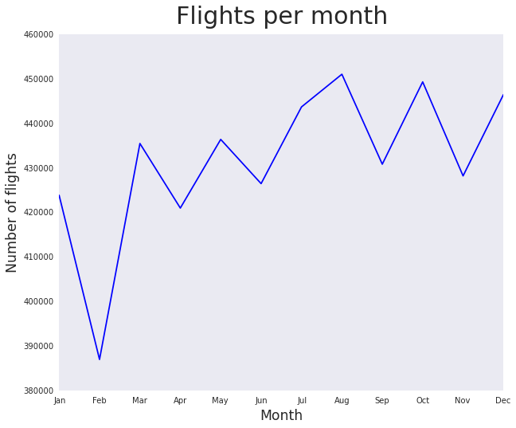

```python
y_data = query_column(month_flights, 1)
linechart("Flights per month", MONTHS_SHORT, y_data, "Month", "Number of flights")
```

**Comment 3.1**  
One relevant information which can be observed is the low number of flights in February with the respect of the other months. Now we are considering only the flights in the 1994, so we do not have a view of the number of flights in the months before January. Assuming that there was a similar trend for flights in the last months of the 1993, we could assume that the drop of the number of flights in the initial months is due to the fact people, in general, do not flight after the Christmas Holidays. A reasonable assumption is that people prefere to flight during holidays at the end of the year.  
Anyway, we should remember that february is the month with the least number of days.  
Another consideration is that we are looking at the flights and not at the number of passengers: it means that we do not have enough information to understand how full the planes actually were.

### Question 3.2:

Is there any relationship between the number of flights and the days of the week? Plot a bar chart and interpret the figure.  
**NOTE:** You should study both global aggregates (irrespectively of the month of the year), and monthly aggregates (day statistics, for each different month of the year).  
By answering this question, we could learn about the importance of the weekend/weekday feature for our predictive task.

```python
res = sqlContext.sql("SELECT day_of_week, COUNT(*) AS res FROM flights GROUP BY day_of_week ORDER BY day_of_week")
res.show()

daily_week_flights = df.groupBy(df.day_of_week).count().orderBy(df.day_of_week).collect()
#print_results(daily_week_flights, DAYS_LONG, "flights")
```

```
+-----------+------+
|day_of_week|   res|
+-----------+------+
|          1|754636|
|          2|756532|
|          3|756864|
|          4|751537|
|          5|751531|
|          6|695245|
|          7|713703|
+-----------+------+
```

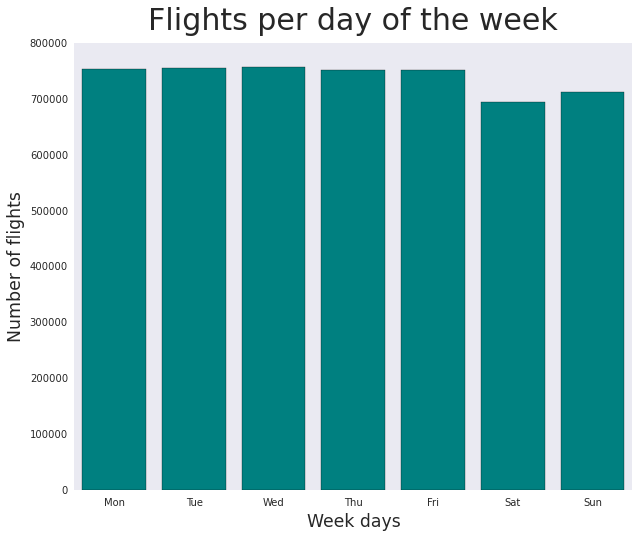

```python
y_data = query_column(daily_week_flights, 1)

barchart_simple("Flights per day of the week", DAYS_SHORT, y_data, "Week days", "Number of flights")
```

**Interpretation**  
Here we are considering the distribution of the number of flights in the days of the weeks. The distribution is quite uniform: weekends are characterized by lower values

```python
res = sqlContext.sql("SELECT month, day_of_week, COUNT(*) AS res FROM flights GROUP BY month, day_of_week ORDER BY month, day_of_week")
res.show(10)

daily_week_flights_per_month = df.groupBy(df.month, df.day_of_week).count().orderBy(df.month, df.day_of_week).collect()

#print("Number of flights per day of the week on a monthly basis: {}".format(str(daily_week_flights_per_month)))
```

```
+-----+-----------+-----+
|month|day_of_week|  res|
+-----+-----------+-----+
|    1|          1|70761|
|    1|          2|56327|
|    1|          3|55944|
|    1|          4|55870|
|    1|          5|56041|
|    1|          6|62488|
|    1|          7|66430|
|    2|          1|56645|
|    2|          2|56549|
|    2|          3|56460|
+-----+-----------+-----+
only showing top 10 rows
```

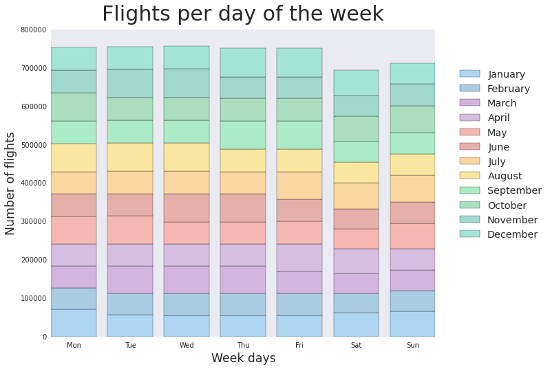

```python
y_data = query_grouping(daily_week_flights_per_month, 1, 0, 2)

barchart_cumulative("Flights per day of the week", DAYS_SHORT, y_data, "Week days", "Number of flights", MONTHS_LONG)
```

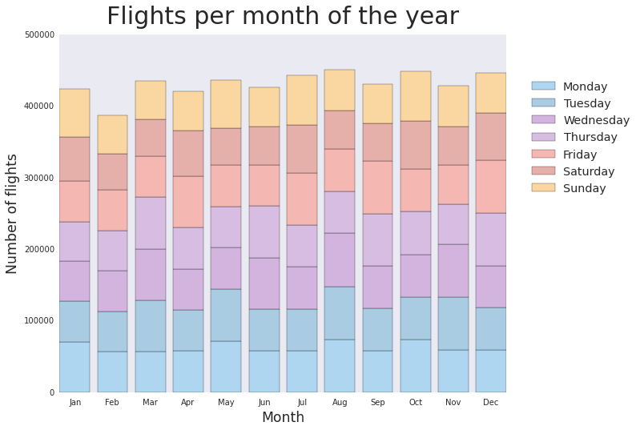

```python
y_data = query_grouping(daily_week_flights_per_month, 0, 1, 2)

barchart_cumulative("Flights per month of the year", MONTHS_SHORT, y_data, "Month", "Number of flights", DAYS_LONG)
```

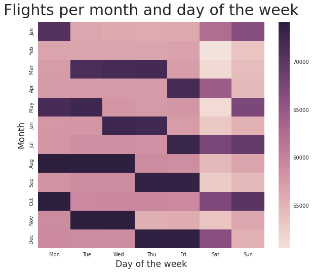

```python
grid_chart("Flights per month and day of the week", y_data, DAYS_SHORT, MONTHS_SHORT, "Day of the week", "Month")
```

**Comment 2.1**  
From the graph above, which is in our opinion the most immediate to read between the ones proposed, we can observe that in general there are less flights during the weekends. The number of flights in the working days of the week remains, considering a global point of view, similar for each day of the week: what changes are the months for which that day is the "most preferred one". We can also state that on Sundays there are more flights with respect to Saturdays.  
As noticed before, February is the month with the least number of flights and the most uniform distribution of flights through the week.

As said before, weekends have the lowest number of flights: a possible assumption could be that people who travel for work, each days, do not travel during the week-ends. Keeping that in mind, consider that we are only observing the flights and not the number of people. It's possible that airline companies provides more flights to help workmen travel during the weekdays and arrive in time, according to their needs.

### Question 3.3

How many flights in different days of months and in different hours of days?  
**NOTE:** Similarly to the previous note, you need to compute both global statistcs and monthly statistics.  
Plot bar charts, and interpret your figures.

```python
# FLIGHTS PER DAY OF MONTH -- GLOBAL SCALE

res = sqlContext.sql("SELECT day_of_month, COUNT(*) AS number_of_flights FROM flights GROUP BY day_of_month ORDER BY day_of_month")
res.show(10)

flight_day_month = df.groupBy(df.day_of_month).count().orderBy(df.day_of_month).collect()
#print("Number of flights per day of the month -- global: {}".format(str(flight_day_month)))
```

```
+------------+-----------------+
|day_of_month|number_of_flights|
+------------+-----------------+
|           1|           169674|
|           2|           169829|
|           3|           168678|
|           4|           169399|
|           5|           168423|
|           6|           170650|
|           7|           172210|
|           8|           170674|
|           9|           170077|
|          10|           170252|
+------------+-----------------+
only showing top 10 rows
```

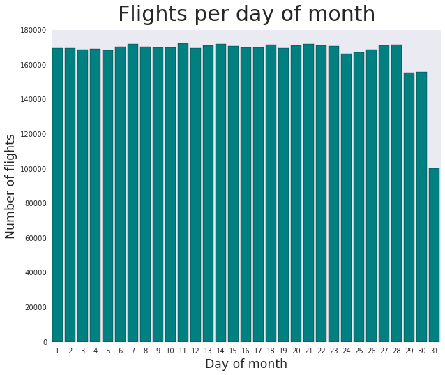

```python
y_data = query_column(flight_day_month, 1)

barchart_simple("Flights per day of month", DAYS_NUMBER, y_data, "Day of month", "Number of flights")
```

**Interpretation**  
Here we are considering the distribution of the number of flights in the day of months. The distribution results to be uniform: the drop we experience on the right-most columns is due to the fact not all the months have 31 days.

```python
# FLIGHTS PER HOUR OF DAY -- GLOBAL SCALE
res = sqlContext.sql("SELECT INT(scheduled_departure_time/100)%24 AS hour, COUNT(*) AS number_of_flights FROM flights GROUP BY INT(scheduled_departure_time/100)%24 ORDER BY INT(scheduled_departure_time/100)%24")
res.show(10)

flight_hour_day = df.groupBy(round(df.scheduled_departure_time/100-0.5)%24).count().orderBy(round(df.scheduled_departure_time/100-0.5)%24).collect()
#print("Number of flights per hour of the day -- global: {}".format(str(flight_hour_day)))
```

```
+----+-----------------+
|hour|number_of_flights|
+----+-----------------+
|   0|            13642|
|   1|            12825|
|   2|             2842|
|   3|              564|
|   4|              486|
|   5|            13357|
|   6|           257486|
|   7|           398796|
|   8|           397060|
|   9|           341597|
+----+-----------------+
only showing top 10 rows
```

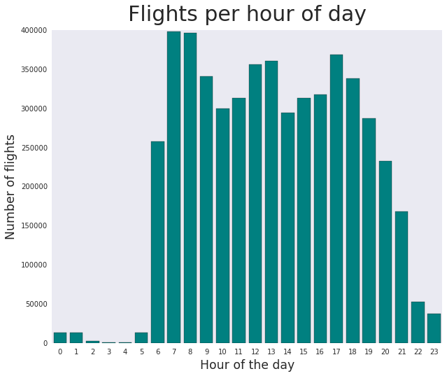

```python
y_data = query_column(flight_hour_day, 1)

barchart_simple("Flights per hour of day", HOURS, y_data, "Hour of the day", "Number of flights")
```

**Interpretation**  
Here we are considering the distribution of the number of flights for all the hours of the day.  
We have already computed a statistic about the percentage of night flights (from 18:00 to 06:00), observing that only one fifth of the flights took place in this range. Indeed, from this picture we observe a distribution which has very sharp variance in the middle, while moving from the 5:00 am to the 6:00 am. The 7:00 am and 8:00 am are the hours with the highest number of flights. Other peaks can be noticed also during the lunchtime or between 17:00 and 18:00. After 18:00, the number of flights starts to drop more and more significantly.

What we can assume is that ariline companies offer more flights to cover the hours from which people tend to move for work in the morning and come back in the evening. One useful usage of this kind of statistic could be manage the platform, understanding when the airport need to handle more traffic of people.

```python
# FLIGHTS PER MONTH AND DAY OF MONTH -- MONTHLY SCALE
res = sqlContext.sql("SELECT month, day_of_month, COUNT(*) AS number_of_flights FROM flights GROUP BY month, day_of_month ORDER BY month, day_of_month")
res.show(10)

flight_month_day_month = df.groupBy(df.month, df.day_of_month).count().orderBy(df.month, df.day_of_month).collect()
#print("Number of flights per month and day of the month -- monthly: {}".format(str(flight_month_day_month)))
```

```
+-----+------------+-----------------+
|month|day_of_month|number_of_flights|
+-----+------------+-----------------+
|    1|           1|            12158|
|    1|           2|            13579|
|    1|           3|            14204|
|    1|           4|            14183|
|    1|           5|            14122|
|    1|           6|            14049|
|    1|           7|            14072|
|    1|           8|            12605|
|    1|           9|            13228|
|    1|          10|            14122|
+-----+------------+-----------------+
only showing top 10 rows
```

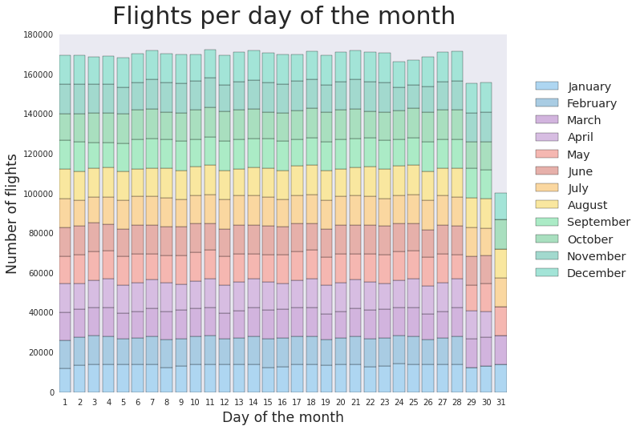

```python
y_data = query_grouping(flight_month_day_month, 1, 0, 2)

barchart_cumulative("Flights per day of the month", DAYS_NUMBER, y_data, "Day of the month", "Number of flights", MONTHS_LONG)
```

[figure not shown]

```python
# zero values for non-existing days of certain months alterate the color mapping in a way that it becomes impossible to analyse properly the resulting graph and retrieve useful information
# so, we want the least value to be the second lowest available one
vmin = min(query_column(flight_month_day_month, 2))

# draw the chart
grid_chart("Flights per month and day of the month", y_data, MONTHS_SHORT, DAYS_NUMBER, "Day of the week", "Day of the month", vmin=vmin)
```

**Interpretation**  
This chart represents, with a color, the number of flights for each day of the year. It highlights a pattern: if we look at it per columns, we can identify the weeks. Grey cells refer to non-existing days of the year 1994.  
It is interensting to notice that we have very few flights for Thanksgiving day (24th and 25th November) and also for Christmas (24th and 25th December).

```python
# FLIGHTS PER MONTH AND HOUR OF DAY -- MONTHLY SCALE
res = sqlContext.sql("SELECT month, INT(scheduled_departure_time/100)%24 AS hour, COUNT(*) AS number_of_flights FROM flights GROUP BY month, INT(scheduled_departure_time/100)%24 ORDER BY month, INT(scheduled_departure_time/100)%24")
res.show(10)

flight_month_hour_day = df.groupBy(df.month, (round(df.scheduled_departure_time/100 - 0.5)%24).alias('hour')).count().orderBy('month', 'hour').withColumn('hour', col('hour').cast('int')).collect()
#print("Number of flights per month and hour of the day -- monthly: {}".format(str(flight_month_hour_day)))
```

```
+-----+----+-----------------+
|month|hour|number_of_flights|
+-----+----+-----------------+
|    1|   0|             1154|
|    1|   1|              901|
|    1|   2|              238|
|    1|   3|               62|
|    1|   4|               33|
|    1|   5|             1017|
|    1|   6|            21360|
|    1|   7|            31184|
|    1|   8|            32814|
|    1|   9|            28242|
+-----+----+-----------------+
only showing top 10 rows
```

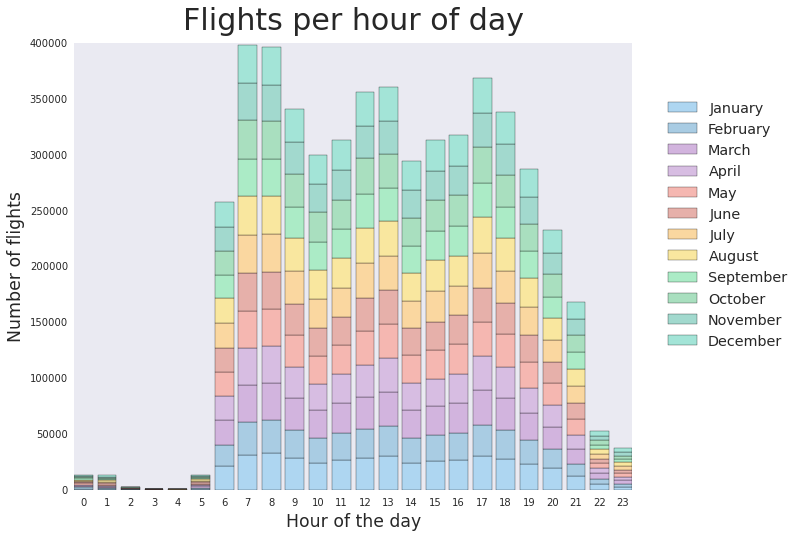

```python
y_data = query_grouping(flight_month_hour_day, 1, 0, 2)

barchart_cumulative("Flights per hour of day", HOURS, y_data, "Hour of the day", "Number of flights", MONTHS_LONG)
```

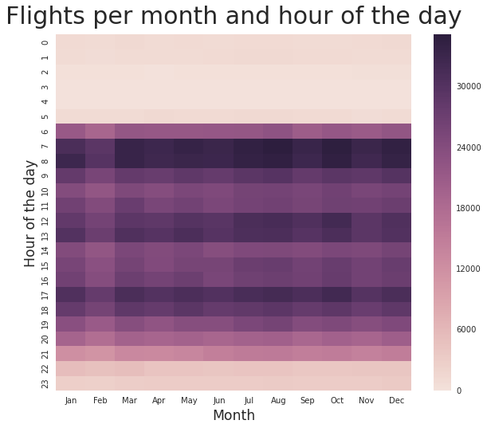

```python
grid_chart("Flights per month and hour of the day", y_data, MONTHS_SHORT, HOURS, "Month", "Hour of the day")
```

**Interpretation**  
Here we are considering the distribution of flights per hour, considering separetely every month of the year.  
We do not observe anithing in particular: flights per hour tend to have the same behaviour for each month. This makes us think that people's choice of a flight is mostly driven by the departure time. The period of the year can influence the total number of tourists between the passengers, but here is impossible to establish because of the aggregated information we are analysing.

```python
# EVERY-HOURS DEPARTURES -- DAY OF MONTH GLOBAL SCALE

res = sqlContext.sql("SELECT day_of_month, INT(scheduled_departure_time/100)%24 AS hour, COUNT(*) AS number_of_flights FROM flights GROUP BY day_of_month, INT(scheduled_departure_time/100)%24 ORDER BY day_of_month, INT(scheduled_departure_time/100)%24")
res.show(10)

hours_day_month = df.groupBy(df.day_of_month, (round(df.scheduled_departure_time/100 - 0.5)%24).alias('hour')).count().orderBy('day_of_month', 'hour').withColumn('hour', col('hour').cast('int')).collect()
#print("Number of flights per day of the week: {}".format(str(hours_day_month)))
```

```
+------------+----+-----------------+
|day_of_month|hour|number_of_flights|
+------------+----+-----------------+
|           1|   0|              451|
|           1|   1|              411|
|           1|   2|               93|
|           1|   3|               19|
|           1|   4|               14|
|           1|   5|              437|
|           1|   6|             8405|
|           1|   7|            13006|
|           1|   8|            12972|
|           1|   9|            11113|
+------------+----+-----------------+
only showing top 10 rows
```

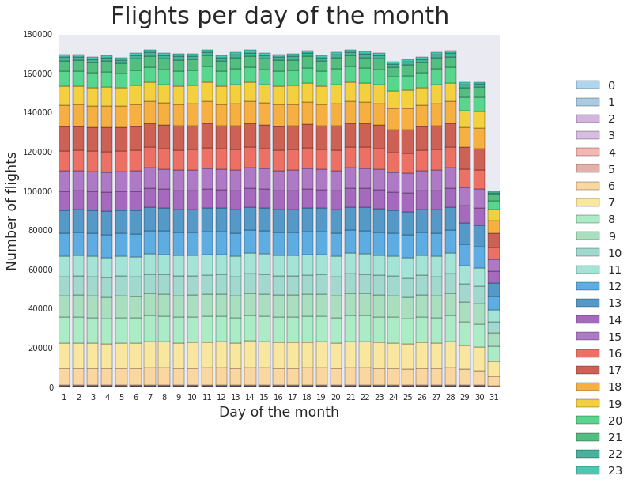

```python
y_data = query_grouping(hours_day_month, 0, 1, 2)

barchart_cumulative("Flights per day of the month", DAYS_NUMBER, y_data, "Day of the month", "Number of flights", HOURS)
```

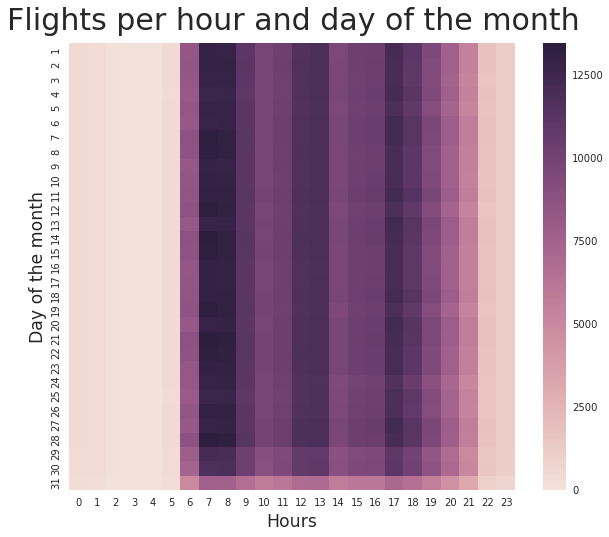

```python
grid_chart("Flights per hour and day of the month", y_data, HOURS, DAYS_NUMBER, "Hour", "Day of the month")
```

**Interpretation**  
We are now considering how flights are distributed through days, considering aggregated months information. In particular, we consider the scheduled departure time.  
The result is similar to what we have obtained in the previous graphs: while chosing a flight, people are mostly driven by the hour of the departure. The aggregated information does not allow us to identify holidays, neither festivals or other possible events

```python
# GRANULARITY HOURS DEPARTURES -- DAY OF MONTH GLOBAL SCALE
res = sqlContext.sql("SELECT day_of_month, INT(scheduled_departure_time/400)%6 AS hour_interval, COUNT(*) AS number_of_flights FROM flights GROUP BY day_of_month, INT(scheduled_departure_time/400)%6 ORDER BY day_of_month, INT(scheduled_departure_time/400)%6")
res.show(10)

hours_day_month_gran = df.groupBy(df.day_of_month, (round(df.scheduled_departure_time/400-0.5)%6).alias('hour_interval')).count().orderBy('day_of_month', 'hour_interval').withColumn('hour_interval', col('hour_interval').cast('int')).collect()
#print("Number of flights per day of the week: {}".format(str(hours_day_month_gran)))
```

```
+------------+-------------+-----------------+
|day_of_month|hour_interval|number_of_flights|
+------------+-------------+-----------------+
|           1|            0|              974|
|           1|            1|            21862|
|           1|            2|            44190|
|           1|            3|            43403|
|           1|            4|            43160|
|           1|            5|            16085|
|           2|            0|              971|
|           2|            1|            21899|
|           2|            2|            44383|
|           2|            3|            43510|
+------------+-------------+-----------------+
only showing top 10 rows
```

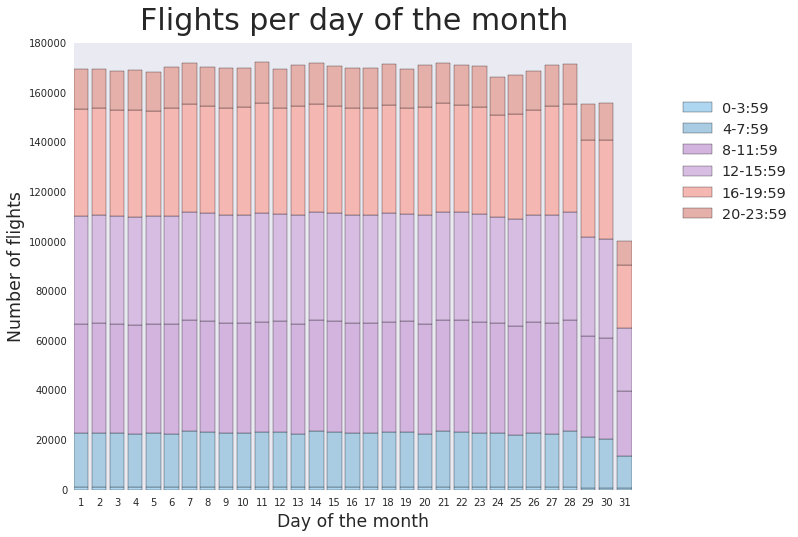

```python
y_data = query_grouping(hours_day_month_gran, 0, 1, 2)
legend_names = ['0-3:59', '4-7:59', '8-11:59', '12-15:59', '16-19:59', '20-23:59']

barchart_cumulative("Flights per day of the month", DAYS_NUMBER, y_data, "Day of the month", "Number of flights", legend_names)
```

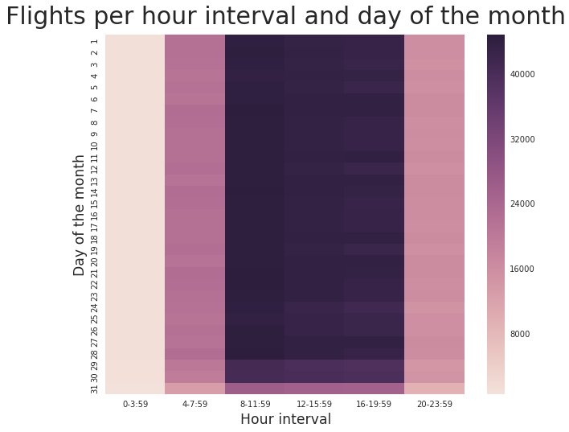

```python
grid_chart("Flights per hour interval and day of the month", y_data, legend_names, DAYS_NUMBER, "Hour interval", "Day of the month")
```

**Interpretation**  
This graph is similar as the previous one, but the analysis considers ranges of hours (we have a different granularity).  
Same observations done before apply here.

### Question 3.4

Which are the **top 20** busiest airports? Compute this in terms of the inbound, outbound and total number of flights.

```python
# TOP 20 INBOUND
res = sqlContext.sql("SELECT dest_airport, COUNT(*) AS res FROM flights GROUP BY dest_airport ORDER BY res DESC LIMIT 20")
res.show()

top_20_inbound = df\
                    .groupBy(df.dest_airport)\
                    .count()\
                    .orderBy("count", ascending=0)\
                    .take(20)
```

```
+------------+------+
|dest_airport|   res|
+------------+------+
|         ORD|283720|
|         DFW|260249|
|         ATL|221588|
|         LAX|152959|
|         STL|152800|
|         DEN|144099|
|         PHX|140979|
|         DTW|139435|
|         PIT|131962|
|         CLT|130321|
|         MSP|124758|
|         SFO|117245|
|         EWR|117223|
|         IAH|104409|
|         LGA|101498|
|         BOS| 99331|
|         LAS| 94948|
|         PHL| 93312|
|         DCA| 87670|
|         MCO| 76600|
+------------+------+
```

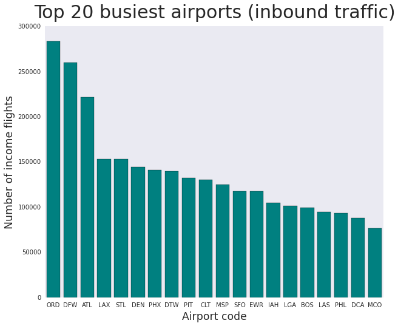

```python
x_names = query_column(top_20_inbound, 0)
y_data = query_column(top_20_inbound, 1)

barchart_simple("Top 20 busiest airports (inbound traffic)", x_names, y_data, "Airport code", "Number of income flights")
```

```python
# TOP 20 OUTBOUND flights
res = sqlContext.sql("SELECT src_airport, COUNT(*) AS res FROM flights GROUP BY src_airport ORDER BY res DESC LIMIT 20")
res.show()

top_20_outbound = df\
                    .groupBy(df.src_airport)\
                    .count()\
                    .orderBy("count", ascending=0)\
                    .take(20)
```

```
+-----------+------+
|src_airport|   res|
+-----------+------+
|        ORD|277741|
|        DFW|256274|
|        ATL|221486|
|        LAX|153494|
|        STL|151609|
|        DEN|141427|
|        PHX|139581|
|        DTW|136837|
|        PIT|130977|
|        CLT|129391|
|        MSP|123222|
|        SFO|118233|
|        EWR|116768|
|        IAH|104182|
|        LGA|101864|
|        BOS|100365|
|        LAS| 94972|
|        PHL| 93585|
|        DCA| 88445|
|        MCO| 77120|
+-----------+------+
```

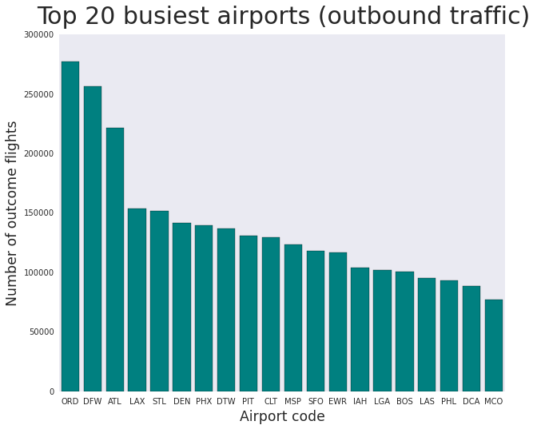

```python
x_names = query_column(top_20_outbound, 0)
y_data = query_column(top_20_outbound, 1)

barchart_simple("Top 20 busiest airports (outbound traffic)", x_names, y_data, "Airport code", "Number of outcome flights")
```

**Observation**  
These top 20 list of busy airports (inbound and outboutnd) are equal: for these reason, their sum (total inbound and outbound traffic of the airport) will have the same ranking

```python
# TOP 20 total flight
query1 = "SELECT src_airport, COUNT(*) AS res1 FROM flights GROUP BY src_airport"
query2 = "SELECT dest_airport, COUNT(*) AS res2 FROM flights GROUP BY dest_airport"
res = sqlContext.sql("SELECT src_airport AS airport_id, res1+res2 AS res FROM ({}) AS src, ({}) AS dst WHERE src_airport=dest_airport ORDER BY res DESC LIMIT 20".format(query1, query2))
res.show()

total_inbound = df\
                    .groupBy(df.dest_airport)\
                    .count().withColumnRenamed("count", "count_in")
total_outbound = df\
                    .groupBy(df.src_airport)\
                    .count()\
                    .withColumnRenamed("count", "count_out")

total_joined = total_inbound\
                        .join(total_outbound, total_inbound.dest_airport == total_outbound.src_airport)

top20_total_in_out = total_joined\
                        .select(total_joined.src_airport.alias('airport_id'), (total_joined.count_in+total_joined.count_out).alias('count_in_out'))\
                        .orderBy('count_in_out', ascending=0).limit(20)
```

```
+----------+------+
|airport_id|   res|
+----------+------+
|       ORD|561461|
|       DFW|516523|
|       ATL|443074|
|       LAX|306453|
|       STL|304409|
|       DEN|285526|
|       PHX|280560|
|       DTW|276272|
|       PIT|262939|
|       CLT|259712|
|       MSP|247980|
|       SFO|235478|
|       EWR|233991|
|       IAH|208591|
|       LGA|203362|
|       BOS|199696|
|       LAS|189920|
|       PHL|186897|
|       DCA|176115|
|       MCO|153720|
+----------+------+
```

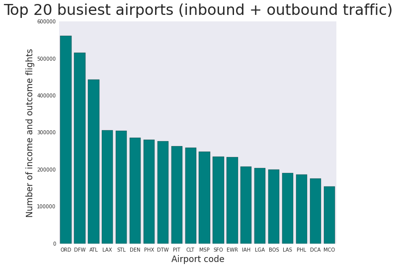

```python
data = top20_total_in_out.take(20)
x_names = query_column(data, 0)
y_data = query_column(data, 1)

barchart_simple("Top 20 busiest airports (inbound + outbound traffic)", x_names, y_data, "Airport code", "Number of income and outcome flights")
```

**Observation**  
Only the first three airports have a traffic level greatly higher than the others. Apart from that, the trend appears to be linearly decreasing.

### Question 3.5

Which are the **top 20** busiest carriers? Compute this in terms of number of flights.

```python
# TOP 20 BUSIEST CARRIERS
res = sqlContext.sql("SELECT carrier, COUNT(*) AS number_of_flights FROM flights GROUP BY carrier ORDER BY number_of_flights DESC LIMIT 20")
res.show()

top20_carriers = df.groupBy(df.carrier).count().orderBy('count', ascending=0).withColumnRenamed('count', 'number_of_flights').limit(20)
```

```
+-------+-----------------+
|carrier|number_of_flights|
+-------+-----------------+
|     DL|           874526|
|     US|           857906|
|     AA|           722277|
|     UA|           638750|
|     WN|           565426|
|     CO|           484834|
|     NW|           482798|
|     TW|           258205|
|     HP|           177851|
|     AS|           117475|
+-------+-----------------+
```

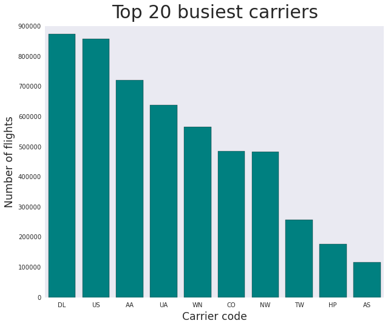

```python
data = top20_carriers.collect()
x_names = query_column(data, 0)
y_data = query_column(data, 1)

barchart_simple("Top 20 busiest carriers", x_names, y_data, "Carrier code", "Number of flights")
```

**Observation**  
We are asked to print the top 20 carriers, but there are only 10 carriers in our dataFrame.

## Question 4

In this series of questions we focus on the computation of statistics about the percentage of delayed flights.

### Question 4.1

What is the percentage of delayed flights for different hours of the day? Plot a bar chart and interpret the figure.

IMPORTANT!

A flight is considered as delayed if it's actual arrival time is more than 15 minutes later than the scheduled arrival time.

```python
# DELAYED FLIGHTS PER HOURS
res = sqlContext.sql("SELECT INT(scheduled_departure_time/100)%24 AS hour, COUNT(*) AS number_of_flights FROM flights WHERE arrival_delay > 15 GROUP BY INT(scheduled_departure_time/100)%24 ORDER BY INT(scheduled_departure_time/100)%24")
res.show(10)

delayed_per_hour = df.filter(df.arrival_delay > 15)\
                        .groupBy(round(df.scheduled_departure_time/100 - 0.5)%24)\
                        .count().orderBy(round(df.scheduled_departure_time/100 - 0.5)%24).collect()
```

```
+----+-----------------+
|hour|number_of_flights|
+----+-----------------+
|   0|             2164|
|   1|             1753|
|   2|              145|
|   3|                6|
|   4|               23|
|   5|              703|
|   6|            18901|
|   7|            38622|
|   8|            49018|
|   9|            46717|
+----+-----------------+
only showing top 10 rows
```

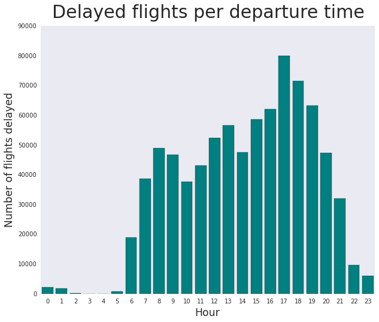

```python
y_data = query_column(delayed_per_hour, 1)

barchart_simple("Delayed flights per departure time", HOURS, y_data, "Hour", "Number of flights delayed")
```

**Interpretation**  
The graph highlights the amount of delayed flights per hour of the day: in particular, we are characterizing a flight considering its scheduled departure time. To understand if there is actually a correlation between delays and the period of the day, we need to compare what we have obtained with the total number of flights (we are going to do it).  
What we can observe so far is a peak of delayed flights during the range of hours from 16:00 to 20:00.

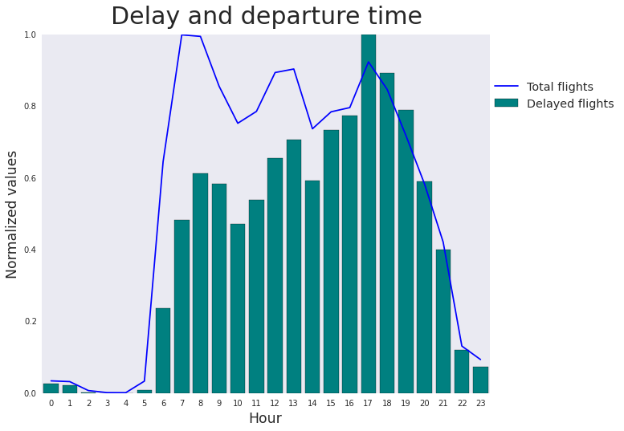

```python
# y_data (bar_data) freshly computed
line_data = query_column(flight_hour_day, 1)

barchart_and_linechart("Delay and departure time", HOURS, y_data, line_data, "Hour", "Delayed flights", "Total flights")
```

**Interpretation**  
We are now comparing total flights per hour and the number of delayed ones.  
Having a comparison between normalized shapes of these graphs, we can see that flights whose scheduled departure time is during daily hours are characterized by a lower fraction of delayed flights (where the blue shape does not fit the green one). Which means: there exist a correlation between departure time and prabability of suffering a delay. It looks like that workers in airports are making efforts in order to contain the probability of a delay during this time interval

```python
# COMPUTING THE PERCENTAGE OF THE DELAYED FLIGHTS PER EACH HOUR OF THE DAY
print('Percentages of delayed flights per hour:')

# compute the data structure for delay percentage per hour
pdf_delay_ratio_per_hour = [list(range(24)), []]

for num, val in enumerate(zip(flight_hour_day, delayed_per_hour)):
    perc = val[1][1] / val[0][1]
    pdf_delay_ratio_per_hour[1].append(perc)
    #print("- hour {}: {}%".format(num, __builtin__.round(perc*100, 2)))
```

```
Percentages of delayed flights per hour:
```

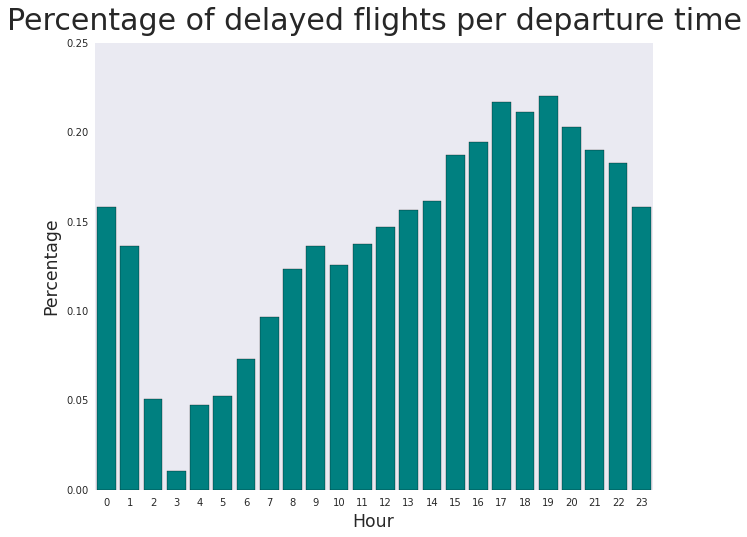

```python
barchart_simple("Percentage of delayed flights per departure time", HOURS, pdf_delay_ratio_per_hour[1], "Hour", "Percentage")
```

**Interpretation**  
Considering the percentage of delayed flights per hour of the day, we can see clearly that there is a correlation between the delay probability and the scheduled departure time. In fact, the graph is not flat and has a sort of bell shape, whose peak is centered between 17:00 and 19:00 (above the 20% of the flights present delays). The minimum delay, instead, is for flights whose departure time is between 3:00 and 4:00.  
Anyway, we are still unable to estimate how much the delay will be strong: we cannot state anything about its mean value (see next question)  
Note: the minimum would have been at 4:00 if we had considered the arrival scheduled time

### Question 4.2

You will realize that saying *"at 4 A.M. there is a very low chance of a flight being delayed"* is not giving you a full picture of the situation. Indeed, it might be true that there is very little probability for an early flight to be delayed, but if it does, the delay might be huge, like 6 hours!

Then, the question is: **which hours of the day are characterized by the largest mean delay?** (you can consider the median too) Plot a Bar chart and explain it.

With data of year 1994, the flight from 3AM to 4AM often depart earlier than in their schedule. The flights in the morning have less delay then in the afternoon and evening.

So, an attentive student should notice here that we have somehow a problem with the definition of delay! Next, we will improve how to represent and visualize data to overcome this problem.

**NOTE**: the following piece of code assumes you correctly answered the previous questions. The naming convention of the DataFrames we use next should be clear enough for you to produce them by answering the questions above.

```python
# COMPUTING THE AVERGE DELAY VALUE FOR EVERY HOUR

avg_delay_per_hour = df.groupBy(round(df.scheduled_departure_time/100 - 0.5)%24)\
                     .mean("arrival_delay").orderBy(round(df.scheduled_departure_time/100 - 0.5)%24)\
                     .collect()
#print("Average delayed per hour: {}".format(str(avg_delay_per_hour)))
print('Mean delay values per hour:')

# compute the data structure for delay averages per hour
pdf_mean_delay_per_hour = [list(range(24)), []]

for num, val in enumerate(avg_delay_per_hour):
    pdf_mean_delay_per_hour[1].append(val[1])
    #print("- hour {}: {:>10}".format(num, __builtin__.round(val[1], 2)))
```

```
Mean delay values per hour:
```

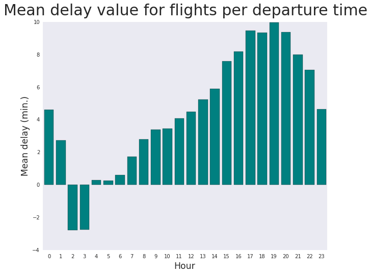

```python
barchart_simple("Mean delay value for flights per departure time", HOURS, pdf_mean_delay_per_hour[1], "Hour", "Mean delay (min.)")
```

**Interpretation**  
Here we are considering the mean delay value for flights having different scheduled departure times.  
Now, with respect to the delay probability graph, we are able to observe that the peak of highest mean delays is again centered in the range between 17:00 and 20:00. But there is another peculiarity observation here to make: previously, we were considering the delayed flights but not the ones which arrive earlier. Indeed, we can observe here that the flights from 2:00 to 4:00 have a negative delay: this means that they usually arrive in advance and/or the delayed ones have small delay values.

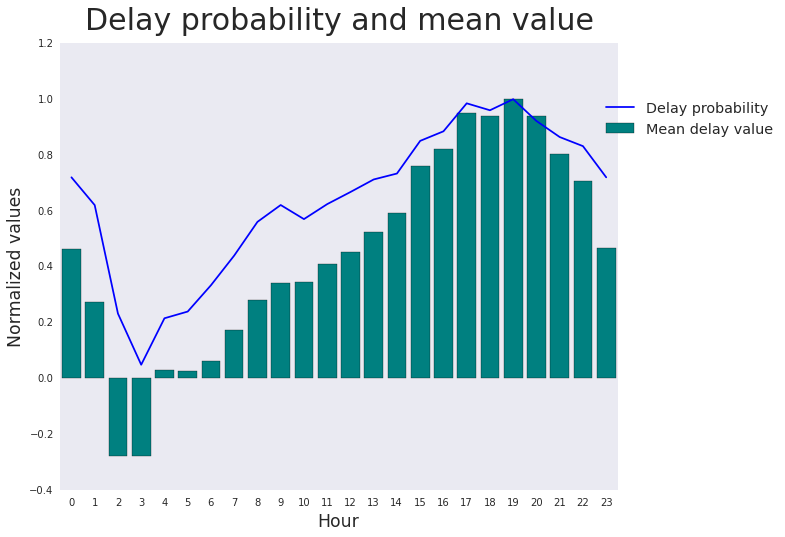

```python
line_data = query_column(delayed_per_hour, 1)

barchart_and_linechart("Delay probability and mean value", HOURS, pdf_mean_delay_per_hour[1], pdf_delay_ratio_per_hour[1], "Hour", "Mean delay value", "Delay probability")
```

**Interpretation**  
Given a certain departure time, we can notice a correlation (shapes are similar) while considering the delay probability for flights and their mean delay value: when the probability is higher, also the mean delay value grows. This is reasonable: in general, we can think that an airport whose majority of flights are delayed is more likely to have a large mean delay value.

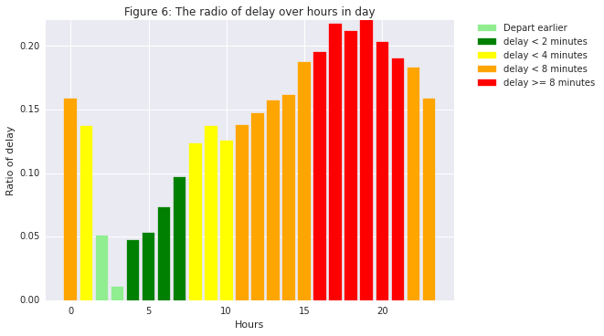

```python
#pdf2 = pd.DataFrame(data=mean_delay_per_hour.collect())
plt.xlabel("Hours")
plt.ylabel("Ratio of delay")
plt.title('Figure 6: The radio of delay over hours in day')
plt.grid(True,which="both",ls="-")
bars = plt.bar(pdf_delay_ratio_per_hour[0], pdf_delay_ratio_per_hour[1], align='center', edgecolor = "black")
for i in range(0, len(bars)):
    color = 'red'
    if pdf_mean_delay_per_hour[1][i] < 0:
        color = 'lightgreen'
    elif pdf_mean_delay_per_hour[1][i] < 2:
        color = 'green'
    elif pdf_mean_delay_per_hour[1][i] < 4:
        color = 'yellow'
    elif pdf_mean_delay_per_hour[1][i] < 8:
        color = 'orange'

    bars[i].set_color(color)

patch1 = mpatches.Patch(color='lightgreen', label='Depart earlier')
patch2 = mpatches.Patch(color='green', label='delay < 2 minutes')
patch3 = mpatches.Patch(color='yellow', label='delay < 4 minutes')
patch4 = mpatches.Patch(color='orange', label='delay < 8 minutes')
patch5 = mpatches.Patch(color='red', label='delay >= 8 minutes')

plt.legend(handles=[patch1, patch2, patch3, patch4, patch5], bbox_to_anchor=(1.05, 1), loc=2, borderaxespad=0.)
plt.margins(0.05, 0)
plt.show()
```

This example shows us that the way representing results are also important.

### Question 4.3

Plot a bar chart to show the percentage of delayed flights over days in a month. Discuss your findings from the figure.

```python
# DELAYED FLIGHTS PER DAY OF THE MONTH
res = sqlContext.sql("SELECT day_of_month, COUNT(*) AS delayed_flights FROM flights WHERE arrival_delay > 15 GROUP BY day_of_month ORDER BY day_of_month")
res.show(10)

delayed_per_day_of_month = df.filter(df.arrival_delay > 15).groupBy(df.day_of_month).count().orderBy(df.day_of_month).collect()
#print("Number of delayed flights per day of the month: {}".format(str(delayed_per_day_of_month)))
```

```
+------------+---------------+
|day_of_month|delayed_flights|
+------------+---------------+
|           1|          23430|
|           2|          23815|
|           3|          23331|
|           4|          22772|
|           5|          26876|
|           6|          26106|
|           7|          26772|
|           8|          26733|
|           9|          30179|
|          10|          29086|
+------------+---------------+
only showing top 10 rows
```

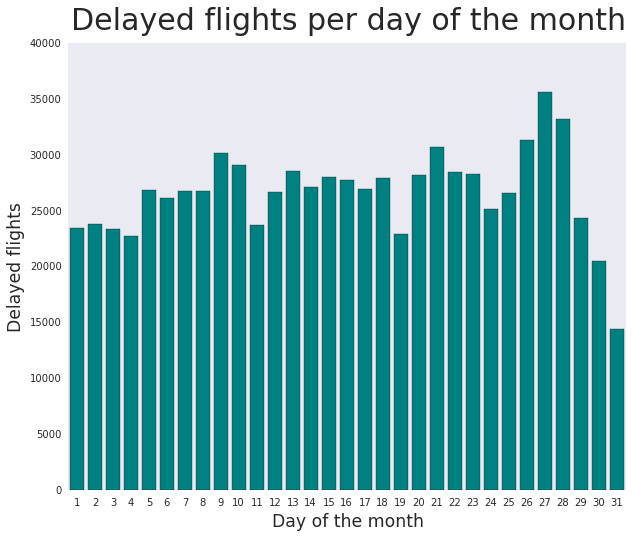

```python
y_data = query_column(delayed_per_day_of_month, 1)

barchart_simple("Delayed flights per day of the month", DAYS_NUMBER, y_data, "Day of the month", "Delayed flights")
```

**Interpretation**  
Here we are considering the number of delayed flights through days of months.  
We can observe an oscillating behaviour, with a peak from the 26th to the 28th. As before, we have the problem that not every month has 31 days: so, last three bars tend to look smaller.  
In order to make a better comparison, we could normalize bar heights dividing them by the number of months for which that day exists. In this way, we would obtain the average number of delayed flights per day of the month: but, actually, the graph would have a different shape only for three bars and this would have not been a great help.

```python
# COMPUTING THE PERCENTAGE OF THE DELAYED FLIGHTS PER EACH DAY OF THE MONTH
print('Percentages of delayed flights per day of the month:')

percentage_delayed_flight_day = [query_column(delayed_per_day_of_month, 0), []]

# print the delay percentage by day
for num, val in enumerate(zip(flight_day_month, delayed_per_day_of_month)):
    perc =  __builtin__.round(val[1][1] / val[0][1]*100, 2)
    percentage_delayed_flight_day[1].append(perc)
    #print("- day {}: {:>9}%".format(num+1, perc))
```

```
Percentages of delayed flights per day of the month:
```

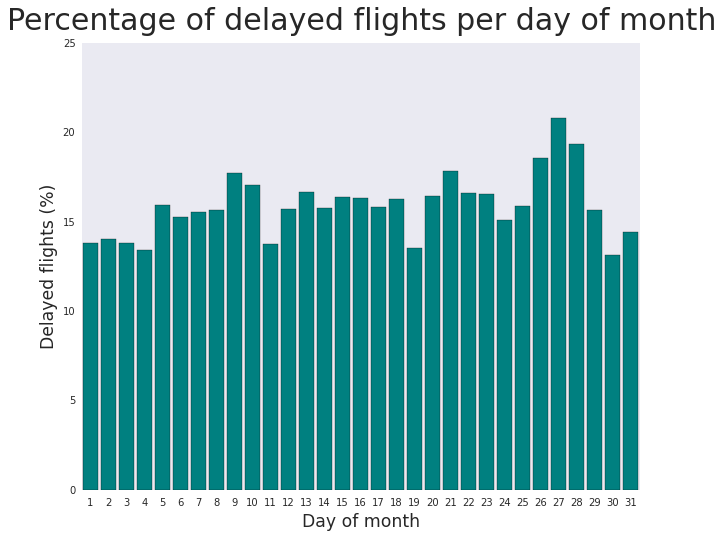

```python
barchart_simple("Percentage of delayed flights per day of month", DAYS_NUMBER, percentage_delayed_flight_day[1], "Day of month", "Delayed flights (%)")
```

**interpretation**  
Here we are considering the percentages of the delayed flights for different days of the months.  
Proceeding in this way, we do not care anymore the fact that only some months have more than 28 days: last three bars have now more uniform values

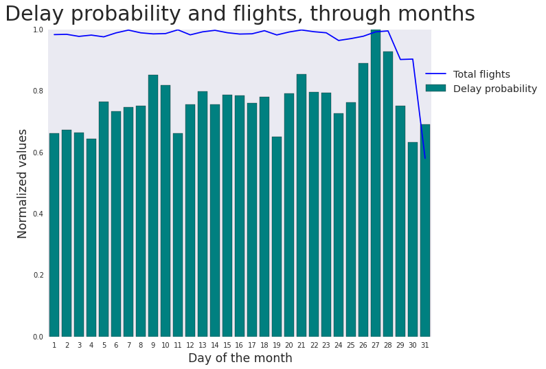

```python
line_data = query_column(flight_day_month, 1)
barchart_and_linechart("Delay probability and flights, through months", DAYS_NUMBER, percentage_delayed_flight_day[1], line_data, "Day of the month", "Delay probability", "Total flights")
```

**Interpretation**  
The situation here is strange: the green graph looks like a constant one, with some added noise. The peak from 26th to 28th is difficult to explain: apart from this region, it looks like there is not a correlation between delays and the departure day of the month.  
**Remember**: the blue curve is not normalized for this case. Its last values are affected by the fact that not every month has the same number of days

### Question 4.4

Plot a bar chart to show the percentage of delayed flights over days in a week. Discuss your findings from the figure.

```python
# DELAYED FLIGHTS PER DAY OF THE WEEK
res = sqlContext.sql("SELECT day_of_week, COUNT(*) AS delayed_flights FROM flights WHERE arrival_delay > 15 GROUP BY day_of_week ORDER BY day_of_week")
res.show()

delayed_per_day_of_week = df.filter(df.arrival_delay > 15)\
                            .groupBy(df.day_of_week).count().orderBy(df.day_of_week).collect()
#print("Number of delayed flights per day of the week: {}".format(str(delayed_per_day_of_week)))
```

```
+-----------+---------------+
|day_of_week|delayed_flights|
+-----------+---------------+
|          1|         115725|
|          2|         108355|
|          3|         129154|
|          4|         139747|
|          5|         137358|
|          6|          91702|
|          7|         103824|
+-----------+---------------+
```

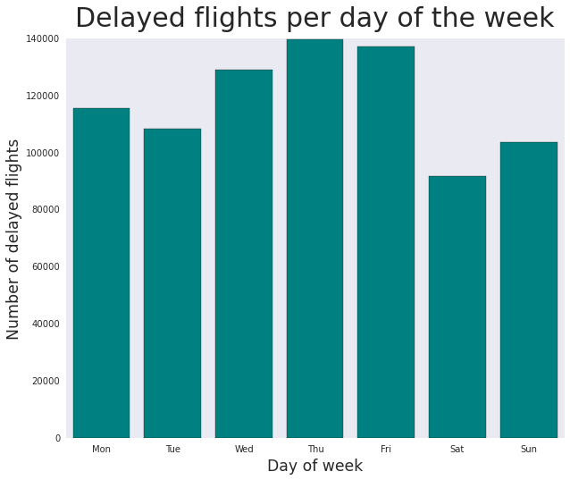

```python
y_data = query_column(delayed_per_day_of_week, 1)

barchart_simple("Delayed flights per day of the week", DAYS_SHORT, y_data, "Day of week", "Number of delayed flights")
```

**Interpretation**  
Here we are considering the number of flights per day of the week.  
From the figure, we can notice that Saturday is characterized with the least number of flights delayed, while the days in the middle of the week are those with the highest number of delayed flights. But we still have to understand if the reason of this behaviour is the day of week, or its usual total number of flights.

```python
# COMPUTING THE PERCENTAGE OF THE DELAYED FLIGHTS PER EACH DAY OF THE WEEK
print('Percentages of delayed flights per day of the week:')

percentage_delayed_flight_day_week = [query_column(delayed_per_day_of_week, 0), []]

for num, val in enumerate(zip(daily_week_flights, delayed_per_day_of_week)):
    perc =  __builtin__.round(val[1][1] / val[0][1]*100, 2)
    percentage_delayed_flight_day_week[1].append(perc)
    #print("- day {}: {}%".format(num+1, perc))
```

```
Percentages of delayed flights per day of the week:
```

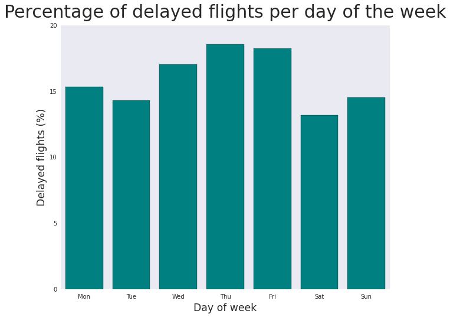

```python
barchart_simple("Percentage of delayed flights per day of the week", DAYS_SHORT, percentage_delayed_flight_day_week[1], "Day of week", "Delayed flights (%)")
```

[figure not shown]

```python
y_data = query_column(delayed_per_day_of_week, 1)
barchart_and_linechart("Delay probability and flights, through weeks", DAYS_SHORT, percentage_delayed_flight_day_week[1], y_data, "Day of week", "Delay probability", "Total flights")
```